# BLSA Biomarker Analysis

Runze Cui

20 May, 2023

# Raw BLSA Dataset:

## 1. Check the Biomarkers’ distributions for raw data:

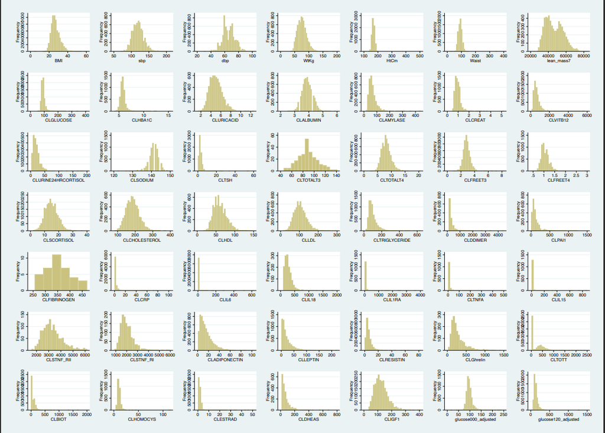

Raw Biomarkers’ Distributions

## 2. Log-transformed and get rid of the outliers:

$$Rules :\begin{cases} X_{i} \geq\mu +
5\sigma \rightarrow NA\\X_{i} \leq\mu - 5\sigma \rightarrow
NA\end{cases}$$

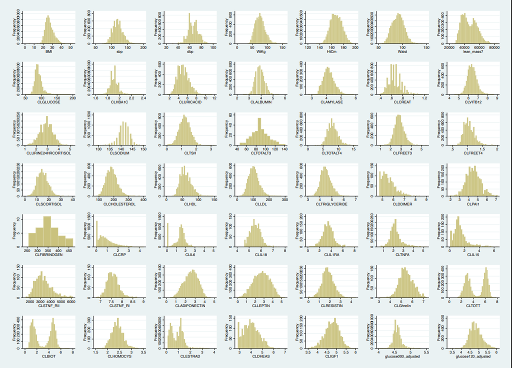

Log Transformed Without Outliers

## 3. Exponential it back and using clinical/percentile cutoffs to recode normal/abnormal for each of the biomarkers.

- Summary table for biomarkers:

```r
cor_table_2.1_df =   tibble(
  "Biomarker"  =    factor(c("Adiponectin",
                             "Adjusted Fasting Glucose",
                             "Albumin",
                             "Amylase",
                             "BMI",
                             "Waist circumference",
                             "Bioavailable Testosterone",
                             "Cholesterol",
                             "Composed Systolic blood pressure (mmHg)",
                             "Composed Diastolic blood pressure (mmHg)",
                             "Core Body Temperature (F)",
                             "Creatinine, Serum",
                             "CRP",
                             "D Dimer",
                             "Dehydroepiandrosterone Sulfate",
                             "Estradiol",
                             "Fibrinogen",
                             "Free T3 (pg/ml)",
                             "Free T4 (ng/ml)",
                             "Ghrelin",
                             "HBA1C (%)",
                             "HDL-Cholesterol",
                             "Homocysteine",
                             "IL15",
                             "IL18",
                             "IL6",
                             "IL1RA",
                             "insulin-like growth factor 1",
                             "LDL-Cholesterol",
                             "leptin",
                             "plasminogen activitor inhibitor 1",
                             "resistin",
                             "Serum cortisol (morning)",
                             "sodium",
                             "STNF-RI",
                             "STNF-RII",
                             "TNFA",
                             "Total T3",
                             "Total T4",
                             "Total testosterone",
                             "Triglycerides",
                             "TSH",
                             "uric acid",
                             "Urine24 cortisol, free (ug/24hrs)",
                             "VIT 12")),
  "Nonmissing obs N" =    c(N("adiponectin")$N_obs,
                            N("AFG")$N_obs,
                            N("albumin")$N_obs,
                            N("amylase")$N_obs,
                            N("bmi")$N_obs,
                            N("waist_circumference")$N_obs,
                            N("bio_testosterone")$N_obs,
                            N("cholesterol")$N_obs,
                            N("systolic_bp")$N_obs,
                            N("diastolic_bp")$N_obs,
                            N("corebody_temp")$N_obs,
                            N("creatinine_serum")$N_obs,
                            N("crp")$N_obs,
                            N("d_dimer")$N_obs,
                            N("dehy_sulfate")$N_obs,
                            N("estradiol")$N_obs,
                            N("fibrinogen")$N_obs,
                            N("free_t3")$N_obs,
                            N("free_t4")$N_obs,
                            N("ghrelin")$N_obs,
                            N("hba1c")$N_obs,
                            N("hdl")$N_obs,
                            N("homocysteine")$N_obs,
                            N("il15")$N_obs,
                            N("il18")$N_obs,
                            N("il6")$N_obs,
                            N("il1ra")$N_obs,
                            N("insu_gf")$N_obs,
                            N("ldl")$N_obs,
                            N("leptin")$N_obs,
                            N("pai")$N_obs,
                            N("resistin")$N_obs,
                            N("serum_cortisol")$N_obs,
                            N("sodium")$N_obs,
                            N("stnf_r1")$N_obs,
                            N("stnf_r2")$N_obs,
                            N("tnfa")$N_obs,
                            N("total_t3")$N_obs,
                            N("total_t4")$N_obs,
                            N("total_testosterone")$N_obs,
                            N("triglycerides")$N_obs,
                            N("tsh")$N_obs,
                            N("uric_acid")$N_obs,
                            N("ur24_cortisol")$N_obs,
                            N("vb12")$N_obs),
  "Nonmissing indi N" =    c(N("adiponectin")$N_indi,
                            N("AFG")$N_indi,
                            N("albumin")$N_indi,
                            N("amylase")$N_indi,
                            N("bmi")$N_indi,
                            N("waist_circumference")$N_indi,
                            N("bio_testosterone")$N_indi,
                            N("cholesterol")$N_indi,
                            N("systolic_bp")$N_indi,
                            N("diastolic_bp")$N_indi,
                            N("corebody_temp")$N_indi,
                            N("creatinine_serum")$N_indi,
                            N("crp")$N_indi,
                            N("d_dimer")$N_indi,
                            N("dehy_sulfate")$N_indi,
                            N("estradiol")$N_indi,
                            N("fibrinogen")$N_indi,
                            N("free_t3")$N_indi,
                            N("free_t4")$N_indi,
                            N("ghrelin")$N_indi,
                            N("hba1c")$N_indi,
                            N("hdl")$N_indi,
                            N("homocysteine")$N_indi,
                            N("il15")$N_indi,
                            N("il18")$N_indi,
                            N("il6")$N_indi,
                            N("il1ra")$N_indi,
                            N("insu_gf")$N_indi,
                            N("ldl")$N_indi,
                            N("leptin")$N_indi,
                            N("pai")$N_indi,
                            N("resistin")$N_indi,
                            N("serum_cortisol")$N_indi,
                            N("sodium")$N_indi,
                            N("stnf_r1")$N_indi,
                            N("stnf_r2")$N_indi,
                            N("tnfa")$N_indi,
                            N("total_t3")$N_indi,
                            N("total_t4")$N_indi,
                            N("total_testosterone")$N_indi,
                            N("triglycerides")$N_indi,
                            N("tsh")$N_indi,
                            N("uric_acid")$N_indi,
                            N("ur24_cortisol")$N_indi,
                            N("vb12")$N_indi),
  "Mean"  =               c(mean(blsa_clean$adiponectin, na.rm = T),
                            mean(blsa_clean$AFG, na.rm = T),
                            mean(blsa_clean$albumin, na.rm = T),
                            mean(blsa_clean$amylase, na.rm = T),
                            mean(blsa_clean$bmi, na.rm = T),
                            mean(blsa_clean$waist_circumference, na.rm = T),
                            mean(blsa_clean$bio_testosterone, na.rm = T),
                            mean(blsa_clean$cholesterol, na.rm = T),
                            mean(blsa_clean$systolic_bp, na.rm = T),
                            mean(blsa_clean$diastolic_bp, na.rm = T),
                            mean(blsa_clean$corebody_temp, na.rm = T),
                            mean(blsa_clean$creatinine_serum, na.rm = T),
                            mean(blsa_clean$crp, na.rm = T),
                            mean(blsa_clean$d_dimer, na.rm = T),
                            mean(blsa_clean$dehy_sulfate, na.rm = T),
                            mean(blsa_clean$estradiol, na.rm = T),
                            mean(blsa_clean$fibrinogen, na.rm = T),
                            mean(blsa_clean$free_t3, na.rm = T),
                            mean(blsa_clean$free_t4, na.rm = T),
                            mean(blsa_clean$ghrelin, na.rm = T),
                            mean(blsa_clean$hba1c, na.rm = T),
                            mean(blsa_clean$hdl, na.rm = T),
                            mean(blsa_clean$homocysteine, na.rm = T),
                            mean(blsa_clean$il15, na.rm = T),
                            mean(blsa_clean$il18, na.rm = T),
                            mean(blsa_clean$il6, na.rm = T),
                            mean(blsa_clean$il1ra, na.rm = T),
                            mean(blsa_clean$insu_gf, na.rm = T),
                            mean(blsa_clean$ldl, na.rm = T),
                            mean(blsa_clean$leptin, na.rm = T),
                            mean(blsa_clean$pai, na.rm = T),
                            mean(blsa_clean$resistin, na.rm = T),
                            mean(blsa_clean$serum_cortisol, na.rm = T),
                            mean(blsa_clean$sodium, na.rm = T),
                            mean(blsa_clean$stnf_r1, na.rm = T),
                            mean(blsa_clean$stnf_r2, na.rm = T),
                            mean(blsa_clean$tnfa, na.rm = T),
                            mean(blsa_clean$total_t3, na.rm = T),
                            mean(blsa_clean$total_t4, na.rm = T),
                            mean(blsa_clean$total_testosterone, na.rm = T),
                            mean(blsa_clean$triglycerides, na.rm = T),
                            mean(blsa_clean$tsh, na.rm = T),
                            mean(blsa_clean$uric_acid, na.rm = T),
                            mean(blsa_clean$ur24_cortisol, na.rm = T),
                            mean(blsa_clean$vb12, na.rm = T)),
  "Standard deviation" =   c(sd(blsa_clean$adiponectin, na.rm = T),
                             sd(blsa_clean$AFG, na.rm = T),
                             sd(blsa_clean$albumin, na.rm = T),
                             sd(blsa_clean$amylase, na.rm = T),
                             sd(blsa_clean$bmi, na.rm = T),
                             sd(blsa_clean$waist_circumference, na.rm = T),
                             sd(blsa_clean$bio_testosterone, na.rm = T),
                             sd(blsa_clean$cholesterol, na.rm = T),
                             sd(blsa_clean$systolic_bp, na.rm = T),
                             sd(blsa_clean$diastolic_bp, na.rm = T),
                             sd(blsa_clean$corebody_temp, na.rm = T),
                             sd(blsa_clean$creatinine_serum, na.rm = T),
                             sd(blsa_clean$crp, na.rm = T),
                             sd(blsa_clean$d_dimer, na.rm = T),
                             sd(blsa_clean$dehy_sulfate, na.rm = T),
                             sd(blsa_clean$estradiol, na.rm = T),
                             sd(blsa_clean$fibrinogen, na.rm = T),
                             sd(blsa_clean$free_t3, na.rm = T),
                             sd(blsa_clean$free_t4, na.rm = T),
                             sd(blsa_clean$ghrelin, na.rm = T),
                             sd(blsa_clean$hba1c, na.rm = T),
                             sd(blsa_clean$hdl, na.rm = T),
                             sd(blsa_clean$homocysteine, na.rm = T),
                             sd(blsa_clean$il15, na.rm = T),
                             sd(blsa_clean$il18, na.rm = T),
                             sd(blsa_clean$il6, na.rm = T),
                             sd(blsa_clean$il1ra, na.rm = T),
                             sd(blsa_clean$insu_gf, na.rm = T),
                             sd(blsa_clean$ldl, na.rm = T),
                             sd(blsa_clean$leptin, na.rm = T),
                             sd(blsa_clean$pai, na.rm = T),
                             sd(blsa_clean$resistin, na.rm = T),
                             sd(blsa_clean$serum_cortisol, na.rm = T),
                             sd(blsa_clean$sodium, na.rm = T),
                             sd(blsa_clean$stnf_r1, na.rm = T),
                             sd(blsa_clean$stnf_r2, na.rm = T),
                             sd(blsa_clean$tnfa, na.rm = T),
                             sd(blsa_clean$total_t3, na.rm = T),
```

```r
                             sd(blsa_clean$total_t4, na.rm = T),
                             sd(blsa_clean$total_testosterone, na.rm = T),
                             sd(blsa_clean$triglycerides, na.rm = T),
                             sd(blsa_clean$tsh, na.rm = T),
                             sd(blsa_clean$uric_acid, na.rm = T),
                             sd(blsa_clean$ur24_cortisol, na.rm = T),
                             sd(blsa_clean$vb12, na.rm = T)),
  "Min" =                   c(min(blsa_clean$adiponectin, na.rm = T),
                              min(blsa_clean$AFG, na.rm = T),
                              min(blsa_clean$albumin, na.rm = T),
                              min(blsa_clean$amylase, na.rm = T),
                              min(blsa_clean$bmi, na.rm = T),
                              min(blsa_clean$waist_circumference, na.rm = T),
                              min(blsa_clean$bio_testosterone, na.rm = T),
                              min(blsa_clean$cholesterol, na.rm = T),
                              min(blsa_clean$systolic_bp, na.rm = T),
                              min(blsa_clean$diastolic_bp, na.rm = T),
                              min(blsa_clean$corebody_temp, na.rm = T),
                              min(blsa_clean$creatinine_serum, na.rm = T),
                              min(blsa_clean$crp, na.rm = T),
                              min(blsa_clean$d_dimer, na.rm = T),
                              min(blsa_clean$dehy_sulfate, na.rm = T),
                              min(blsa_clean$estradiol, na.rm = T),
                              min(blsa_clean$fibrinogen, na.rm = T),
                              min(blsa_clean$free_t3, na.rm = T),
                              min(blsa_clean$free_t4, na.rm = T),
                              min(blsa_clean$ghrelin, na.rm = T),
                              min(blsa_clean$hba1c, na.rm = T),
                              min(blsa_clean$hdl, na.rm = T),
                              min(blsa_clean$homocysteine, na.rm = T),
                              min(blsa_clean$il15, na.rm = T),
                              min(blsa_clean$il18, na.rm = T),
                              min(blsa_clean$il6, na.rm = T),
                              min(blsa_clean$il1ra, na.rm = T),
                              min(blsa_clean$insu_gf, na.rm = T),
                              min(blsa_clean$ldl, na.rm = T),
                              min(blsa_clean$leptin, na.rm = T),
                              min(blsa_clean$pai, na.rm = T),
                              min(blsa_clean$resistin, na.rm = T),
                              min(blsa_clean$serum_cortisol, na.rm = T),
                              min(blsa_clean$sodium, na.rm = T),
                              min(blsa_clean$stnf_r1, na.rm = T),
                              min(blsa_clean$stnf_r2, na.rm = T),
                              min(blsa_clean$tnfa, na.rm = T),
                              min(blsa_clean$total_t3, na.rm = T),
                              min(blsa_clean$total_t4, na.rm = T),
                              min(blsa_clean$total_testosterone, na.rm = T),
                              min(blsa_clean$triglycerides, na.rm = T),
                              min(blsa_clean$tsh, na.rm = T),
                              min(blsa_clean$uric_acid, na.rm = T),
                              min(blsa_clean$ur24_cortisol, na.rm = T),
                              min(blsa_clean$vb12, na.rm = T)),
  "max" =                    c(max(blsa_clean$adiponectin, na.rm = T),
                               max(blsa_clean$AFG, na.rm = T),
                               max(blsa_clean$albumin, na.rm = T),
                               max(blsa_clean$amylase, na.rm = T),
                               max(blsa_clean$bmi, na.rm = T),
                               max(blsa_clean$waist_circumference, na.rm = T),
                               max(blsa_clean$bio_testosterone, na.rm = T),
                               max(blsa_clean$cholesterol, na.rm = T),
                               max(blsa_clean$systolic_bp, na.rm = T),
                               max(blsa_clean$diastolic_bp, na.rm = T),
                               max(blsa_clean$corebody_temp, na.rm = T),
                               max(blsa_clean$creatinine_serum, na.rm = T),
                               max(blsa_clean$crp, na.rm = T),
                               max(blsa_clean$d_dimer, na.rm = T),
                               max(blsa_clean$dehy_sulfate, na.rm = T),
                               max(blsa_clean$estradiol, na.rm = T),
                               max(blsa_clean$fibrinogen, na.rm = T),
                               max(blsa_clean$free_t3, na.rm = T),
                               max(blsa_clean$free_t4, na.rm = T),
                               max(blsa_clean$ghrelin, na.rm = T),
                               max(blsa_clean$hba1c, na.rm = T),
                               max(blsa_clean$hdl, na.rm = T),
                               max(blsa_clean$homocysteine, na.rm = T),
                               max(blsa_clean$il15, na.rm = T),
                               max(blsa_clean$il18, na.rm = T),
                               max(blsa_clean$il6, na.rm = T),
                               max(blsa_clean$il1ra, na.rm = T),
                               max(blsa_clean$insu_gf, na.rm = T),
                               max(blsa_clean$ldl, na.rm = T),
                               max(blsa_clean$leptin, na.rm = T),
                               max(blsa_clean$pai, na.rm = T),
                               max(blsa_clean$resistin, na.rm = T),
                               max(blsa_clean$serum_cortisol, na.rm = T),
                               max(blsa_clean$sodium, na.rm = T),
                               max(blsa_clean$stnf_r1, na.rm = T),
                               max(blsa_clean$stnf_r2, na.rm = T),
                               max(blsa_clean$tnfa, na.rm = T),
                               max(blsa_clean$total_t3, na.rm = T),
                               max(blsa_clean$total_t4, na.rm = T),
                               max(blsa_clean$total_testosterone, na.rm = T),
                               max(blsa_clean$triglycerides, na.rm = T),
                               max(blsa_clean$tsh, na.rm = T),
                               max(blsa_clean$uric_acid, na.rm = T),
                               max(blsa_clean$ur24_cortisol, na.rm = T),
                               max(blsa_clean$vb12, na.rm = T))) %>%
```

```r
  knitr::kable(digits = 3)
cor_table_2.1_df
```

| Biomarker | Nonmissing obs N | Nonmissing indi N | Mean | Standard deviation | Min | max |
| --- | --- | --- | --- | --- | --- | --- |
| Adiponectin | 5950 | 1632 | 15.389 | 11.728 | 0.470 | 103.391 |
| Adjusted Fasting Glucose | 5963 | 1623 | 97.906 | 14.212 | 55.000 | 195.000 |
| Albumin | 6839 | 1757 | 3.896 | 0.365 | 2.500 | 5.900 |
| Amylase | 3559 | 1352 | 67.646 | 30.417 | 15.000 | 358.000 |
| BMI | 7246 | 1806 | 27.000 | 4.794 | 13.290 | 60.630 |
| Waist circumference | 6780 | 1791 | 90.562 | 12.594 | 52.100 | 146.500 |
| Bioavailable Testosterone | 4503 | 1504 | 60.790 | 79.805 | 0.200 | 1692.000 |
| Cholesterol | 6651 | 1674 | 185.680 | 37.790 | 82.000 | 376.000 |
| Composed Systolic blood pressure (mmHg) | 6867 | 1793 | 119.200 | 16.119 | 70.000 | 211.000 |
| Composed Diastolic blood pressure (mmHg) | 6866 | 1793 | 65.932 | 9.093 | 38.000 | 102.000 |
| Core Body Temperature (F) | 4927 | 1469 | 97.718 | 0.518 | 93.900 | 99.500 |
| Creatinine, Serum | 6822 | 1756 | 0.956 | 0.249 | 0.460 | 2.600 |
| CRP | 7391 | 1869 | 2.414 | 4.563 | 0.000 | 76.500 |
| D Dimer | 1298 | 804 | 330.469 | 322.152 | 111.000 | 4438.000 |
| Dehydroepiandrosterone Sulfate | 2060 | 1083 | 70.602 | 59.627 | 16.000 | 688.000 |
| Estradiol | 4603 | 1511 | 1.937 | 2.630 | 0.100 | 35.300 |
| Fibrinogen | 37 | 36 | 352.054 | 54.360 | 257.000 | 469.000 |
| Free T3 (pg/ml) | 5597 | 1562 | 2.842 | 0.497 | 1.120 | 5.730 |
| Free T4 (ng/ml) | 6583 | 1665 | 1.057 | 0.182 | 0.420 | 2.000 |
| Ghrelin | 1698 | 1031 | 279.886 | 194.768 | 19.700 | 1430.000 |
| HBA1C (%) | 5115 | 1469 | 5.810 | 0.577 | 4.100 | 9.400 |
| HDL-Cholesterol | 6651 | 1674 | 61.044 | 17.371 | 17.000 | 147.000 |
| Homocysteine | 2775 | 1270 | 10.403 | 2.972 | 3.700 | 37.300 |
| IL15 | 1384 | 936 | 11.038 | 43.122 | 0.050 | 735.920 |
| IL18 | 1387 | 938 | 278.378 | 149.873 | 99.000 | 1876.200 |
| IL6 | 7384 | 1868 | 3.806 | 4.669 | 0.000 | 107.000 |
| IL1RA | 1324 | 907 | 67.238 | 206.108 | 0.290 | 3670.230 |
| insulin-like growth factor 1 | 2281 | 1145 | 124.686 | 47.242 | 33.000 | 407.000 |
| LDL-Cholesterol | 6632 | 1672 | 104.968 | 32.973 | 20.000 | 295.000 |
| leptin | 5964 | 1635 | 21.903 | 22.437 | 0.000 | 220.900 |
| plasminogen activitor inhibitor 1 | 2435 | 1173 | 125.254 | 130.371 | 6.000 | 1250.000 |
| resistin | 2574 | 1185 | 6.231 | 5.163 | 0.000 | 82.340 |
| Serum cortisol (morning) | 2227 | 1154 | 14.831 | 4.534 | 2.300 | 36.800 |
| sodium | 6829 | 1757 | 141.219 | 2.585 | 129.000 | 150.000 |
| STNF-RI | 1387 | 938 | 2042.456 | 661.170 | 901.720 | 5957.500 |
| STNF-RII | 1379 | 938 | 3309.950 | 821.548 | 1572.100 | 6150.900 |
| TNFA | 1377 | 931 | 11.505 | 16.468 | 0.810 | 204.230 |
| Total T3 | 251 | 251 | 88.478 | 17.782 | 46.000 | 141.000 |
| Total T4 | 6594 | 1673 | 8.152 | 1.702 | 3.100 | 20.600 |
| Total testosterone | 4771 | 1538 | 238.940 | 267.136 | 2.900 | 2400.000 |
| Triglycerides | 6648 | 1674 | 99.573 | 52.495 | 20.000 | 636.000 |
| TSH | 6615 | 1672 | 2.637 | 1.543 | 0.004 | 19.651 |
| uric acid | 6639 | 1673 | 5.028 | 1.300 | 1.400 | 12.600 |
| Urine24 cortisol, free (ug/24hrs) | 2197 | 1218 | 20.440 | 14.950 | 2.120 | 187.000 |
| VIT 12 | 6630 | 1672 | 674.762 | 444.261 | 92.000 | 5747.000 |

- Summary table for cutoffs’ information:

```r
cor_table_2.2_df =   tibble(
  "Biomarker"  =    factor(c("Adiponectin",
                             "Adjusted Fasting Glucose",
                             "Albumin",
                             "Amylase",
                             "BMI",
                             "Waist circumference",
                             "Bioavailable Testosterone",
                             "Cholesterol",
                             "Composed Systolic blood pressure (mmHg)",
                             "Composed Diastolic blood pressure (mmHg)",
                             "Core Body Temperature (F)",
                             "Creatinine, Serum",
                             "CRP",
                             "D Dimer",
                             "Dehydroepiandrosterone Sulfate",
                             "Estradiol",
                             "Fibrinogen",
                             "Free T3 (pg/ml)",
                             "Free T4 (ng/ml)",
                             "Ghrelin",
                             "HBA1C (%)",
                             "HDL-Cholesterol",
                             "Homocysteine",
                             "IL15",
                             "IL18",
                             "IL6",
                             "IL1RA",
                             "insulin-like growth factor 1",
                             "LDL-Cholesterol",
                             "leptin",
                             "plasminogen activitor inhibitor 1",
                             "resistin",
                             "Serum cortisol (morning)",
                             "sodium",
                             "STNF-RI",
                             "STNF-RII",
                             "TNFA",
                             "Total T3",
                             "Total T4",
                             "Total testosterone",
                             "Triglycerides",
                             "TSH",
                             "uric acid",
                             "Urine24 cortisol, free (ug/24hrs)",
                             "VIT 12")),
  "N Waves Measured" =    c(wave(adiponectin),
                            wave(AFG),
                            wave(albumin),
                            wave(amylase),
                            wave(bmi),
                            wave(waist_circumference),
                            wave(bio_testosterone),
                            wave(cholesterol),
                            wave(systolic_bp),
                            wave(diastolic_bp),
                            wave(corebody_temp),
                            wave(creatinine_serum),
                            wave(crp),
                            wave(d_dimer),
                            wave(dehy_sulfate),
                            wave(estradiol),
                            wave(fibrinogen),
                            wave(free_t3),
                            wave(free_t4),
                            wave(ghrelin),
                            wave(hba1c),
                            wave(hdl),
                            wave(homocysteine),
                            wave(il15),
                            wave(il18),
                            wave(il6),
                            wave(il1ra),
                            wave(insu_gf),
                            wave(ldl),
                            wave(leptin),
                            wave(pai),
                            wave(resistin),
                            wave(serum_cortisol),
                            wave(sodium),
                            wave(stnf_r1),
                            wave(stnf_r2),
                            wave(tnfa),
                            wave(total_t3),
                            wave(total_t4),
                            wave(total_testosterone),
                            wave(triglycerides),
                            wave(tsh),
                            wave(uric_acid),
                            wave(ur24_cortisol),
                            wave(vb12)),



  "N Observations" =      c(N("adiponectin")$N_obs,
                            N("AFG")$N_obs,
                            N("albumin")$N_obs,
                            N("amylase")$N_obs,
                            N("bmi")$N_obs,
                            N("waist_circumference")$N_obs,
                            N("bio_testosterone")$N_obs,
                            N("cholesterol")$N_obs,
                            N("systolic_bp")$N_obs,
                            N("diastolic_bp")$N_obs,
                            N("corebody_temp")$N_obs,
                            N("creatinine_serum")$N_obs,
                            N("crp")$N_obs,
                            N("d_dimer")$N_obs,
                            N("dehy_sulfate")$N_obs,
                            N("estradiol")$N_obs,
                            N("fibrinogen")$N_obs,
                            N("free_t3")$N_obs,
                            N("free_t4")$N_obs,
                            N("ghrelin")$N_obs,
                            N("hba1c")$N_obs,
                            N("hdl")$N_obs,
                            N("homocysteine")$N_obs,
                            N("il15")$N_obs,
                            N("il18")$N_obs,
                            N("il6")$N_obs,
                            N("il1ra")$N_obs,
                            N("insu_gf")$N_obs,
                            N("ldl")$N_obs,
                            N("leptin")$N_obs,
                            N("pai")$N_obs,
                            N("resistin")$N_obs,
                            N("serum_cortisol")$N_obs,
                            N("sodium")$N_obs,
                            N("stnf_r1")$N_obs,
                            N("stnf_r2")$N_obs,
                            N("tnfa")$N_obs,
                            N("total_t3")$N_obs,
                            N("total_t4")$N_obs,
                            N("total_testosterone")$N_obs,
                            N("triglycerides")$N_obs,
                            N("tsh")$N_obs,
                            N("uric_acid")$N_obs,
                            N("ur24_cortisol")$N_obs,
                            N("vb12")$N_obs),
  "Male Normal Range" =    c("change based on BMI (ug/mL)",
                             "70 - 100 (mg/dl)",
                             "3.4 - 5.4 (g/dL)",
                             "28- 100 (u/L)",
                             "18.5 - 30",
                             "0 - 94 (cm)",
                             "110 - 400 (ng/dL)",
                             "0 - 200 (mg/dL)",
                             "90 - 120 (mmHg)",
                             "60 - 80 (mmHg)",
                             "97 - 99 (F)",
                             "0.74 - 1.35 (mg/dL)",
                             "0 - 10 (ug/mL)",
                             "0 - 500 (mg/mL)",
                             "change based on age (ug/dL)",
                             "1 - 4 (ng/dL)",
                             "200 - 393 (mg/dL)",
                             "1.3 - 4.5 (pg/mL)",
                             "0.9 - 2.3 (ng/dL)",
                             "per: 0% - 80% (pg/mL)",
                             "4.1 - 5.7 (%)",
                             ">= 60 (mg/dL)",
                             "7.1 - 16.3 (umol/L)",
                             "0 - 20 (pg/mL)",
                             "0 - 468 (pg/mL)",
                             "per: 0% - 80% (pg/mL)",
                             "per: 20% - 100% (pg/mL)",
                             "change based on age (ng/mL)",
                             "100 - 129 (mg/dL)",
                             "change based on BMI (ng/mL)",
                             "per: 0% - 80% (ng/mL)",
                             "per: 0% - 80% (ng/mL)",
                             "7 - 25 (ug/dL)",
                             "135 - 145 (mmol/L)",
                             "per: 0% - 80% (pg/mL) ",
                             "per: 0% - 80% (pg/mL) ",
                             "per: 0% - 80% (pg/mL) ",
                             "80 - 200 (ng/mL)",
                             "4.7 - 11.5 (ug/dL)",
                             "240 - 950 (ng/dL)",
                             "0 - 150 (mg/dL)",
                             "0.3 - 4.2",
                             "3.7 - 8 (mg/dL)",
                             "3.5 - 45 (ug/24hrs)",
                             "180 - 914 (pg/mL)"),
  "Female Normal Range" =  c("change based on BMI (ug/mL)",
                             "70 - 100 (mg/dl)",
                             "3.4 - 5.4 (g/dL)",
                             "28- 100 (u/L)",
                             "18.5 - 30",
                             "0 - 80 (cm)",
                             "1 - 19 (ng/dL)",
                             "0 - 200 (mg/dL)",
                             "90 - 120 (mmHg)",
                             "60 - 80 (mmHg)",
                             "97 - 99 (F)",
                             "0.59 - 1.04 (mg/dL)",
                             "0 - 10 (ug/mL)",
                             "0 - 500 (mg/mL)",
                             "change based on age (ug/dL)",
                             "0 - 1 (ng/dL)",
                             "200 - 393 (mg/dL)",
                             "1.3 - 4.5 (pg/mL)",
                             "0.9 - 2.3 (ng/dL)",
                             "per: 0% - 80% (pg/mL)",
                             "4.1 - 5.7 (%)",
                             ">= 60 (mg/dL)",
                             "5.6 - 15.6 (umol/L)",
                             "0 - 20 (pg/mL)",
                             "0 - 468 (pg/mL)",
                             "per: 0% - 80% (pg/mL)",
                             "per: 20% - 100% (pg/mL)",
                             "change based on age (ng/mL)",
                             "100 - 129 (mg/dL)",
                             "change based on BMI (ng/mL)",
                             "per: 0% - 80% (ng/mL)",
                             "per: 0% - 80% (ng/mL)",
                             "7 - 25 (ug/dL)",
                             "135 - 145 (mmol/L)",
                             "per: 0% - 80% (pg/mL)",
                             "per: 0% - 80% (pg/mL)",
                             "per: 0% - 80% (pg/mL)",
                             "80 - 200 (ng/mL)",
                             "4.7 - 11.5 (ug/dL)",
                             "8 - 60 (ng/dL)",
                             "0 - 150 (mg/dL)",
                             "0.3 - 4.2",
                             "2.7 - 6.1 (mg/dL)",
                             "3.5 - 45 (ug/24hrs)",
                             "180 - 914 (pg/mL)"),
```

```r
  "Abnormal Percentage" = c(adiponectin_abper,
                            AFG_abper,
                            albumin_abper,
                            amylase_abper,
                            bmi_abper,
                            waist_circumference_abper,
                            bio_testosterone_abper,
                            cholesterol_abper,
                            systolic_bp_abper,
                            diastolic_bp_abper,
                            corebody_temp_abper,
                            creatinine_serum_abper,
                            crp_abper,
                            d_dimer_abper,
                            dehy_sulfate_abper,
                            estradiol_abper,
                            fibrinogen_abper,
                            free_t3_abper,
                            free_t4_abper,
                            ghrelin_abper,
                            hba1c_abper,
                            hdl_abper,
                            homocysteine_abper,
                            il15_abper,
                            il18_abper,
                            il6_abper,
                            il1ra_abper,
                            insu_gf_abper,
                            ldl_abper,
                            leptin_abper,
                            pai_abper,
                            resistin_abper,
                            serum_cortisol_abper,
                            sodium_abper,
                            stnf_r1_abper,
                            stnf_r2_abper,
                            tnfa_abper,
                            total_t3_abper,
                            total_t4_abper,
                            total_testosterone_abper,
                            triglycerides_abper,
                            tsh_abper,
                            uric_acid_abper,
                            ur24_cortisol_abper,
                            vb12_abper)
)

cor_table_2.2_df  =
  cor_table_2.2_df %>%
  mutate("Source" = row.names(.))

cor_table_2.2_df$url <- c("https://www.mayocliniclabs.com/test-catalog/Overview/75607#Clinical-and-Interpretive",
                        "https://www.mayoclinic.org/diseases-conditions/diabetes/diagnosis-treatment/drc-20371451#:~:text=A%20fasting%20blood%20sugar%20level,separate%20tests%2C%20you%20have%20diabetes.",
                        "https://www.ucsfhealth.org/medical-tests/albumin-blood-(serum)-test",
                        "https://www.mayocliniclabs.com/test-catalog/Overview/8352#Clinical-and-Interpretive",
                        "https://newsnetwork.mayoclinic.org/discussion/mayo-clinic-q-and-a-bmi-is-not-the-only-indicator-of-your-overall-health/",
                        "https://apps.who.int/iris/bitstream/handle/10665/44583/?sequence=1",
                        "https://mlabs.umich.edu/tests/bioavailable-testosterone-panel#:~:text=Bioavailable%20Testosterone%3A%20Males%20Ages%2020,Handbook%20entries%20for%20reference%20ranges.",
                        "https://www.mayoclinic.org/tests-procedures/cholesterol-test/about/pac-20384601",
                        "https://www.mayoclinic.org/diseases-conditions/low-blood-pressure/symptoms-causes/syc-20355465#:~:text=Low%20blood%20pressure%20is%20generally,the%20bottom%20number%20(diastolic).",
                        "https://www.mayoclinic.org/diseases-conditions/high-blood-pressure/in-depth/blood-pressure/art-20050982",
                        "https://medlineplus.gov/ency/article/001982.htm#:~:text=The%20average%20normal%20body%20temperature,by%20an%20infection%20or%20illness.",
                        "https://www.mayoclinic.org/tests-procedures/creatinine-test/about/pac-20384646",
                        "https://www.mayoclinic.org/tests-procedures/c-reactive-protein-test/about/pac-20385228#:~:text=CRP%20is%20measured%20in%20milligrams,greater%20than%2010%20mg%2FL",
                        "https://www.mayocliniclabs.com/test-catalog/Overview/602174#Clinical-and-Interpretive",
                        "https://www.mayocliniclabs.com/test-catalog/Overview/113595#Clinical-and-Interpretive",
                        "https://www.mayocliniclabs.com/test-catalog/Overview/81816#Clinical-and-Interpretive",
                        "https://www.mayocliniclabs.com/test-catalog/Overview/40937#Clinical-and-Interpretive",
                        "https://www.mountsinai.org/health-library/tests/t3-test#:~:text=Normal%20Results&text=Free%20T3%20%2D%2D%20130%20to,per%20liter%20(pmol%2FL",
                        "https://www.mountsinai.org/health-library/tests/free-t4-test#:~:text=Normal%20Results,or%20may%20test%20different%20specimens.",
                        "https://www.mayocliniclabs.com/test-catalog/Overview/57902#Clinical-and-Interpretive",
                        "https://www.mayoclinic.org/tests-procedures/a1c-test/about/pac-20384643#:~:text=Below%205.7%25%20is%20normal.,two%20separate%20tests%20indicates%20diabetes.",
                        "https://www.mayoclinic.org/tests-procedures/cholesterol-test/about/pac-20384601",
                        "https://www.mayocliniclabs.com/test-catalog/Overview/80379#Clinical-and-Interpretive",
                        "https://pubmed.ncbi.nlm.nih.gov/20736143/#:~:text=In%20healthy%20controls%2C%20the%20median,mL%3A%20p%20%3D%200.821%5D.",
                        "https://www.mayocliniclabs.com/test-catalog/Overview/610259#Clinical-and-Interpretive",
                        "https://www.mayocliniclabs.com/test-catalog/Overview/63020#Clinical-and-Interpretive",
                        "https://www.mayocliniclabs.com/test-catalog/Overview/91708#Clinical-and-Interpretive",
                        "https://www.mayocliniclabs.com/test-catalog/Overview/62750#Clinical-and-Interpretive",
                        "https://www.mayoclinic.org/tests-procedures/cholesterol-test/about/pac-20384601",
                        "https://www.mayocliniclabs.com/test-catalog/Overview/91339#Clinical-and-Interpretive",
                        "https://www.mayocliniclabs.com/test-catalog/Overview/86083#Clinical-and-Interpretive",
                        "https://www.ncbi.nlm.nih.gov/pmc/articles/PMC3315035/#:~:text=Normally%2C%20the%20serum%20concentration%20of,et%20al.%2C%202003).",
                        "https://www.mayocliniclabs.com/test-catalog/Overview/8545#Clinical-and-Interpretive",
                        "https://www.mayoclinic.org/diseases-conditions/hyponatremia/symptoms-causes/syc-20373711#:~:text=A%20normal%20blood%20sodium%20level,Certain%20medications.",
                        "NA",
                        "NA",
                        "https://www.mayocliniclabs.com/test-catalog/Overview/63022#Clinical-and-Interpretive",
                        "https://www.mayocliniclabs.com/test-catalog/Overview/8613#Clinical-and-Interpretive",
                        "https://www.mayocliniclabs.com/test-catalog/Overview/8724#Clinical-and-Interpretive",
                        "https://www.mayocliniclabs.com/test-catalog/Overview/8508#Clinical-and-Interpretive",
                        "https://www.mayoclinic.org/tests-procedures/cholesterol-test/about/pac-20384601",
                        "https://www.mayocliniclabs.com/test-catalog/Overview/8939#Clinical-and-Interpretive",
                        "https://www.mayocliniclabs.com/test-catalog/Overview/8440#Clinical-and-Interpretive",
                        "https://www.mayocliniclabs.com/test-catalog/Overview/82948#Clinical-and-Interpretive",
                        "https://www.mayocliniclabs.com/test-catalog/Overview/9154#Clinical-and-Interpretive")
```

```r
cor_table_2.2_df <- cor_table_2.2_df %>%
  mutate("Source" = paste("<a href=\"", url, "\">", "Source", "</a>", sep = "")) %>%
  select("Biomarker", "N Waves Measured", "Male Normal Range", "Female Normal Range", "Abnormal Percentage", "Source")

cor_table_2.2_df = knitr::kable(cor_table_2.2_df, digits = 4, format = "html", escape = FALSE) %>%
  kable_styling(bootstrap_options = c("hover", "condensed"))

cor_table_2.2_df
```

| Biomarker | N Waves Measured | Male Normal Range | Female Normal Range | Abnormal Percentage | Source |
| --- | --- | --- | --- | --- | --- |
| Adiponectin | 32 | change based on BMI (ug/mL) | change based on BMI (ug/mL) | 13.88% | [Source](https://www.mayocliniclabs.com/test-catalog/Overview/75607#Clinical-and-Interpretive) |
| Adjusted Fasting Glucose | 32 | 70 - 100 (mg/dl) | 70 - 100 (mg/dl) | 36.07% | [Source](https://www.mayoclinic.org/diseases-conditions/diabetes/diagnosis-treatment/drc-20371451#:~:text=A%20fasting%20blood%20sugar%20level,separate%20tests%2C%20you%20have%20diabetes.) |
| Albumin | 34 | 3.4 - 5.4 (g/dL) | 3.4 - 5.4 (g/dL) | 5.57% | Source |
| Amylase | 32 | 28- 100 (u/L) | 28- 100 (u/L) | 12.31% | [Source](https://www.mayocliniclabs.com/test-catalog/Overview/8352#Clinical-and-Interpretive) |
| BMI | 34 | 18.5 - 30 | 18.5 - 30 | 23.83% | [Source](https://newsnetwork.mayoclinic.org/discussion/mayo-clinic-q-and-a-bmi-is-not-the-only-indicator-of-your-overall-health/) |
| Waist circumference | 33 | 0 - 94 (cm) | 0 - 80 (cm) | 61.45% | [Source](https://apps.who.int/iris/bitstream/handle/10665/44583/?sequence=1) |
| Bioavailable Testosterone | 32 | 110 - 400 (ng/dL) | 1 - 19 (ng/dL) | 30.42% | [Source](https://mlabs.umich.edu/tests/bioavailable-testosterone-panel#:~:text=Bioavailable%20Testosterone%3A%20Males%20Ages%2020,Handbook%20entries%20for%20reference%20ranges.) |
| Cholesterol | 34 | 0 - 200 (mg/dL) | 0 - 200 (mg/dL) | 32.79% | [Source](https://www.mayoclinic.org/tests-procedures/cholesterol-test/about/pac-20384601) |
| Composed Systolic blood pressure (mmHg) | 33 | 90 - 120 (mmHg) | 90 - 120 (mmHg) | 50.04% | Source |
| Composed Diastolic blood pressure (mmHg) | 33 | 60 - 80 (mmHg) | 60 - 80 (mmHg) | 29.54% | [Source](https://www.mayoclinic.org/diseases-conditions/high-blood-pressure/in-depth/blood-pressure/art-20050982) |
| Core Body Temperature (F) | 32 | 97 - 99 (F) | 97 - 99 (F) | 6.01% | [Source](https://medlineplus.gov/ency/article/001982.htm#:~:text=The%20average%20normal%20body%20temperature,by%20an%20infection%20or%20illness.) |
| Creatinine, Serum | 34 | 0.74 - 1.35 (mg/dL) | 0.59 - 1.04 (mg/dL) | 13.81% | [Source](https://www.mayoclinic.org/tests-procedures/creatinine-test/about/pac-20384646) |
| CRP | 34 | 0 - 10 (ug/mL) | 0 - 10 (ug/mL) | 4.76% | [Source](https://www.mayoclinic.org/tests-procedures/c-reactive-protein-test/about/pac-20385228#:~:text=CRP%20is%20measured%20in%20milligrams,greater%20than%2010%20mg%2FL) |
| D Dimer | 31 | 0 - 500 (mg/mL) | 0 - 500 (mg/mL) | 13.94% | [Source](https://www.mayocliniclabs.com/test-catalog/Overview/602174#Clinical-and-Interpretive) |
| Dehydroepiandrosterone Sulfate | 31 | change based on age (ug/dL) | change based on age (ug/dL) | 1.60% | [Source](https://www.mayocliniclabs.com/test-catalog/Overview/113595#Clinical-and-Interpretive) |
| Estradiol | 31 | 1 - 4 (ng/dL) | 0 - 1 (ng/dL) | 13.34% | [Source](https://www.mayocliniclabs.com/test-catalog/Overview/81816#Clinical-and-Interpretive) |
| Fibrinogen | 16 | 200 - 393 (mg/dL) | 200 - 393 (mg/dL) | 27.03% | [Source](https://www.mayocliniclabs.com/test-catalog/Overview/40937#Clinical-and-Interpretive) |
| Free T3 (pg/ml) | 33 | 1.3 - 4.5 (pg/mL) | 1.3 - 4.5 (pg/mL) | 0.63% | Source |
| Free T4 (ng/ml) | 33 | 0.9 - 2.3 (ng/dL) | 0.9 - 2.3 (ng/dL) | 20.69% | [Source](https://www.mountsinai.org/health-library/tests/free-t4-test#:~:text=Normal%20Results,or%20may%20test%20different%20specimens.) |
| Ghrelin | 31 | per: 0% - 80% (pg/mL) | per: 0% - 80% (pg/mL) | 20.02% | [Source](https://www.mayocliniclabs.com/test-catalog/Overview/57902#Clinical-and-Interpretive) |
| HBA1C (%) | 34 | 4.1 - 5.7 (%) | 4.1 - 5.7 (%) | 59.26% | [Source](https://www.mayoclinic.org/tests-procedures/a1c-test/about/pac-20384643#:~:text=Below%205.7%25%20is%20normal.,two%20separate%20tests%20indicates%20diabetes.) |
| HDL-Cholesterol | 34 | >= 60 (mg/dL) | >= 60 (mg/dL) | 51.32% | [Source](https://www.mayoclinic.org/tests-procedures/cholesterol-test/about/pac-20384601) |
| Homocysteine | 31 | 7.1 - 16.3 (umol/L) | 5.6 - 15.6 (umol/L) | 6.70% | [Source](https://www.mayocliniclabs.com/test-catalog/Overview/80379#Clinical-and-Interpretive) |
| IL15 | 32 | 0 - 20 (pg/mL) | 0 - 20 (pg/mL) | 8.31% | [Source](https://pubmed.ncbi.nlm.nih.gov/20736143/#:~:text=In%20healthy%20controls%2C%20the%20median,mL%3A%20p%20%3D%200.821%5D.) |
| IL18 | 32 | 0 - 468 (pg/mL) | 0 - 468 (pg/mL) | 7.71% | [Source](https://www.mayocliniclabs.com/test-catalog/Overview/610259#Clinical-and-Interpretive) |
| IL6 | 34 | per: 0% - 80% (pg/mL) | per: 0% - 80% (pg/mL) | 20.00% | [Source](https://www.mayocliniclabs.com/test-catalog/Overview/63020#Clinical-and-Interpretive) |
| IL1RA | 32 | per: 20% - 100% (pg/mL) | per: 20% - 100% (pg/mL) | 20.02% | [Source](https://www.mayocliniclabs.com/test-catalog/Overview/91708#Clinical-and-Interpretive) |
| insulin-like growth factor 1 | 31 | change based on age (ng/mL) | change based on age (ng/mL) | 0.92% | [Source](https://www.mayocliniclabs.com/test-catalog/Overview/62750#Clinical-and-Interpretive) |
| LDL-Cholesterol | 34 | 100 - 129 (mg/dL) | 100 - 129 (mg/dL) | 67.29% | [Source](https://www.mayoclinic.org/tests-procedures/cholesterol-test/about/pac-20384601) |
| leptin | 32 | change based on BMI (ng/mL) | change based on BMI (ng/mL) | 0.10% | [Source](https://www.mayocliniclabs.com/test-catalog/Overview/91339#Clinical-and-Interpretive) |
| plasminogen activitor inhibitor 1 | 32 | per: 0% - 80% (ng/mL) | per: 0% - 80% (ng/mL) | 19.88% | [Source](https://www.mayocliniclabs.com/test-catalog/Overview/86083#Clinical-and-Interpretive) |
| resistin | 31 | per: 0% - 80% (ng/mL) | per: 0% - 80% (ng/mL) | 19.97% | Source |
| Serum cortisol (morning) | 30 | 7 - 25 (ug/dL) | 7 - 25 (ug/dL) | 4.85% | [Source](https://www.mayocliniclabs.com/test-catalog/Overview/8545#Clinical-and-Interpretive) |
| sodium | 34 | 135 - 145 (mmol/L) | 135 - 145 (mmol/L) | 5.27% | [Source](https://www.mayoclinic.org/diseases-conditions/hyponatremia/symptoms-causes/syc-20373711#:~:text=A%20normal%20blood%20sodium%20level,Certain%20medications.) |
| STNF-RI | 32 | per: 0% - 80% (pg/mL) | per: 0% - 80% (pg/mL) | 20.04% | Source |
| STNF-RII | 32 | per: 0% - 80% (pg/mL) | per: 0% - 80% (pg/mL) | 20.09% | Source |
| TNFA | 32 | per: 0% - 80% (pg/mL) | per: 0% - 80% (pg/mL) | 20.04% | [Source](https://www.mayocliniclabs.com/test-catalog/Overview/63022#Clinical-and-Interpretive) |
| Total T3 | 25 | 80 - 200 (ng/mL) | 80 - 200 (ng/mL) | 29.88% | [Source](https://www.mayocliniclabs.com/test-catalog/Overview/8613#Clinical-and-Interpretive) |
| Total T4 | 33 | 4.7 - 11.5 (ug/dL) | 4.7 - 11.5 (ug/dL) | 4.55% | [Source](https://www.mayocliniclabs.com/test-catalog/Overview/8724#Clinical-and-Interpretive) |
| Total testosterone | 32 | 240 - 950 (ng/dL) | 8 - 60 (ng/dL) | 11.65% | [Source](https://www.mayocliniclabs.com/test-catalog/Overview/8508#Clinical-and-Interpretive) |
| Triglycerides | 34 | 0 - 150 (mg/dL) | 0 - 150 (mg/dL) | 12.64% | [Source](https://www.mayoclinic.org/tests-procedures/cholesterol-test/about/pac-20384601) |
| TSH | 33 | 0.3 - 4.2 | 0.3 - 4.2 | 13.48% | [Source](https://www.mayocliniclabs.com/test-catalog/Overview/8939#Clinical-and-Interpretive) |
| uric acid | 33 | 3.7 - 8 (mg/dL) | 2.7 - 6.1 (mg/dL) | 10.38% | [Source](https://www.mayocliniclabs.com/test-catalog/Overview/8440#Clinical-and-Interpretive) |
| Urine24 cortisol, free (ug/24hrs) | 32 | 3.5 - 45 (ug/24hrs) | 3.5 - 45 (ug/24hrs) | 5.96% | [Source](https://www.mayocliniclabs.com/test-catalog/Overview/82948#Clinical-and-Interpretive) |
| VIT 12 | 33 | 180 - 914 (pg/mL) | 180 - 914 (pg/mL) | 16.89% | [Source](https://www.mayocliniclabs.com/test-catalog/Overview/9154#Clinical-and-Interpretive) |

```r
head(blsa_clean)
```

```
## # A tibble: 6 × 99
##      id   age gender visit total_lmass MRmean  RMRmean   bmi waist_circumference
##   <dbl> <dbl> <chr>  <dbl>       <dbl>  <dbl>    <dbl> <dbl>               <dbl>
## 1    57    89 M          2         NA   NA    NA        NA                   NA
## 2    57    90 M          3         NA   NA    NA        NA                   NA
## 3    87    83 M         18      52737.  NA    NA        30.5                104
## 4    88    76 M         21      71094.  NA    NA        34.1                119.
## 5    88    79 M         22      61267.  NA    NA        32.9                126.
## 6    88    83 M         23      68565.   1.16  1.69e-5  36.7                121
## # ℹ 90 more variables: systolic_bp <dbl>, diastolic_bp <dbl>, albumin <dbl>,
## #   amylase <dbl>, creatinine_serum <dbl>, vb12 <dbl>, ur24_cortisol <dbl>,
## #   sodium <dbl>, tsh <dbl>, total_t3 <dbl>, total_t4 <dbl>,
## #   total_testosterone <dbl>, free_t3 <dbl>, free_t4 <dbl>,
## #   serum_cortisol <dbl>, cholesterol <dbl>, hdl <dbl>, ldl <dbl>,
## #   triglycerides <dbl>, d_dimer <dbl>, pai <dbl>, fibrinogen <dbl>, crp <dbl>,
## #   il6 <dbl>, il18 <dbl>, il1ra <dbl>, il15 <dbl>, bio_testosterone <dbl>, …
```

## 4. Choose the biomarkers and visits for allostatic load score:

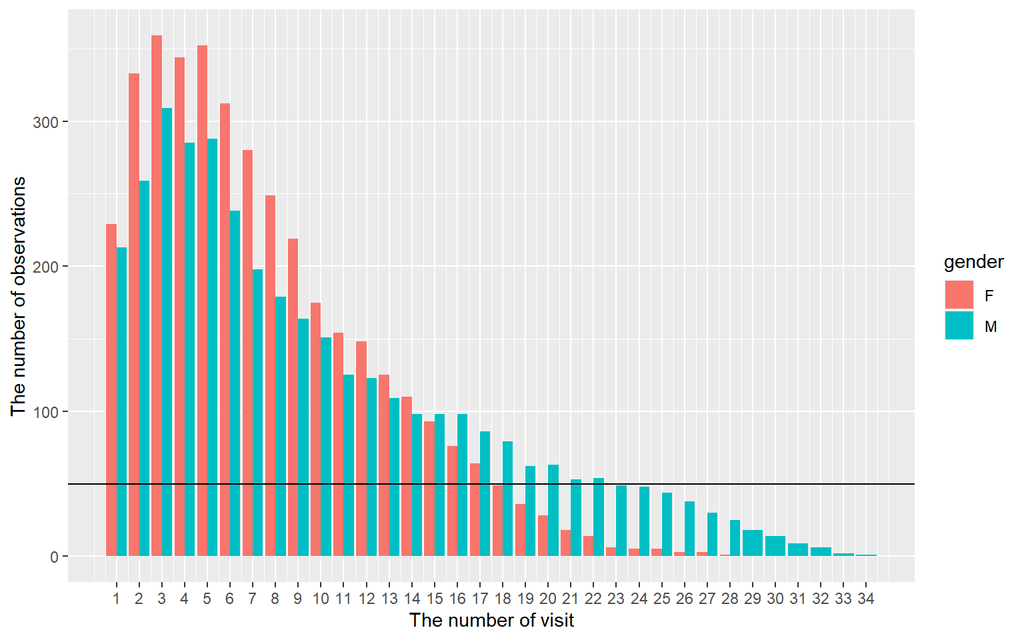

```r
blsa_clean %>%
  select(gender, visit, bmi:uric_acid, -skin_fold) %>%
  ggplot(aes(x = visit, fill = gender)) +
  geom_bar(position = "dodge") +
  labs(x = "The number of visit", y = "The number of observations") +
  geom_hline(yintercept = 50) +
  scale_x_continuous(breaks = seq(1, 34, 1))
```

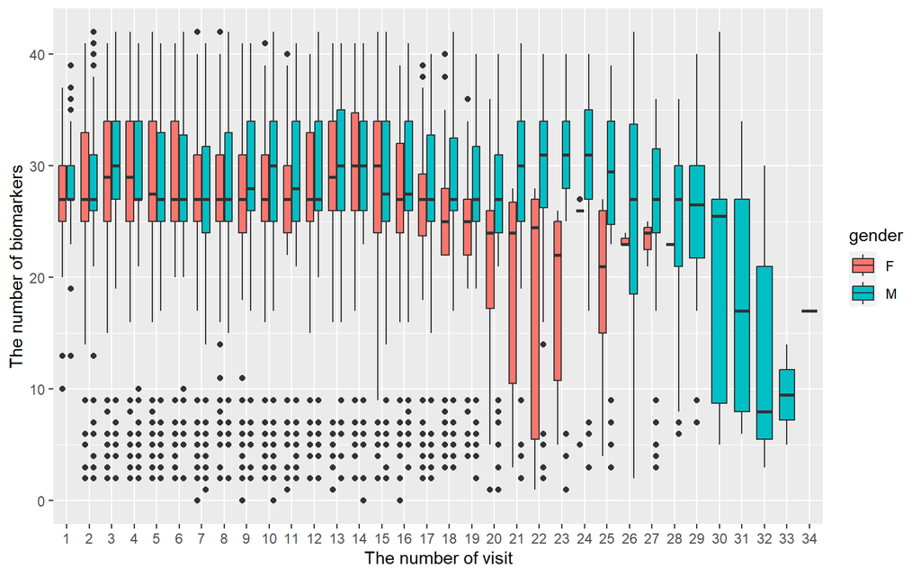

```r
blsa_clean %>%
  select(id, gender, visit, bmi:uric_acid, -skin_fold) %>%
  rowwise() %>%
  mutate(nonmissing_count = sum(!is.na(c_across(bmi:uric_acid)))) %>%
  ggplot(aes(x = factor(visit), y = nonmissing_count, fill = gender)) +
  geom_boxplot() +
  labs(x = "The number of visit", y = "The number of biomarkers")
```

The study chooses the observations with $N(Biomarkers)\geq 24$ and $Visit < 19$ to compute the allostatic load score for further analysis.

# New dataset for AL score computing:

## Generate a new dataset called `new_blsa_clean`:

There is 34 biomarkers are included. Two different independent variables `MRmean` and `RMRmean`, and one more predictor allostatic load score are computed as follows:

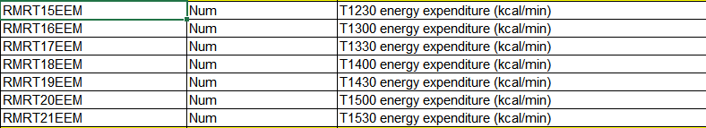

EE table in raw data

$$MRmean_{i} = \mathbb{E}(Energy \;
Expenditure)_{i} = \frac{\sum_{}^{}ee_{}}{7}$$
$$RMRmean_{i} = \frac{MRmean_{i}}{Lean \;
Mass_{i}}=\frac{\mathbb{E}(Energy \; Expenditure)_{i}} {Lean \;
Mass_{i}}$$
$$AL\;score_{i} =
\frac{N(Abnormal)_{i}}{N(Biomarkers)_{i}}$$

```r
new_blsa_clean =
  blsa_clean %>%
  select(c(id,
           visit,
           age,
           gender,
           MRmean,
           RMRmean,
           bmi,
           systolic_bp,
           diastolic_bp,
           waist_circumference,
           hba1c,
           uric_acid,
           albumin,
           amylase,
           creatinine_serum,
           vb12,
           ur24_cortisol,
           sodium,
           tsh,
           total_t4,
           free_t3,
           free_t4,
           serum_cortisol,
           cholesterol,
           hdl,
           ldl,
           triglycerides,
           pai,
           crp,
           il6,
           adiponectin,
           leptin,
           resistin,
           total_testosterone,
           bio_testosterone,
           homocysteine,
           estradiol,
           dehy_sulfate,
           insu_gf,
           AFG,
           bmi_cutoff,
           systolic_bp_cutoff,
           diastolic_bp_cutoff,
           waist_circumference_cutoff,
           hba1c_cutoff,
           uric_acid_cutoff,
           albumin_cutoff,
           amylase_cutoff,
           creatinine_serum_cutoff,
           vb12_cutoff,
           ur24_cortisol_cutoff,
           sodium_cutoff,
           tsh_cutoff,
           total_t4_cutoff,
           free_t3_cutoff,
           free_t4_cutoff,
           serum_cortisol_cutoff,
           cholesterol_cutoff,
           hdl_cutoff,
           ldl_cutoff,
           triglycerides_cutoff,
           pai_percent_cutoff,
           crp_cutoff,
           il6_percent_cutoff,
           adiponectin_cutoff,
           leptin_cutoff,
           resistin_percent_cutoff,
           total_testosterone_cutoff,
           bio_testosterone_cutoff,
           homocysteine_cutoff,
           estradiol_cutoff,
           dehy_sulfate_cutoff,
           insu_gf_cutoff,
           AFG_cutoff))

new_blsa_clean$nbm <- rowSums(!is.na(new_blsa_clean %>% select(bmi:AFG)))
new_blsa_clean  =
  new_blsa_clean %>%
  mutate(aldata = '')
new_blsa_clean$aldata[new_blsa_clean$nbm >= 24] <- 1
new_blsa_clean$aldata[new_blsa_clean$nbm < 24] <- 0

new_blsa_clean =
  new_blsa_clean %>%
  filter(visit < 19) %>%
  filter(aldata == 1)

new_blsa_clean$nab <- rowSums(new_blsa_clean %>% select(bmi_cutoff:AFG_cutoff) == "abnormal")
new_blsa_clean =
  new_blsa_clean %>%
  mutate(al_score = round((nab / nbm) * 34))

head(new_blsa_clean)
```

```
## # A tibble: 6 × 78
##      id visit   age gender MRmean    RMRmean   bmi systolic_bp diastolic_bp
##   <dbl> <dbl> <dbl> <chr>   <dbl>      <dbl> <dbl>       <dbl>        <dbl>
## 1    95    11    81 M      NA     NA          25.1         135           69
## 2    95    12    83 M      NA     NA          24.2         120           70
## 3   166     5    68 M      NA     NA          21.7          NA           NA
## 4   166     6    70 M      NA     NA          22.8         111           62
## 5   166     7    72 M       1.07   0.0000206  22.8         109           67
## 6   166     8    74 M       0.992  0.0000182  22.8         100           59
## # ℹ 69 more variables: waist_circumference <dbl>, hba1c <dbl>, uric_acid <dbl>,
## #   albumin <dbl>, amylase <dbl>, creatinine_serum <dbl>, vb12 <dbl>,
## #   ur24_cortisol <dbl>, sodium <dbl>, tsh <dbl>, total_t4 <dbl>,
## #   free_t3 <dbl>, free_t4 <dbl>, serum_cortisol <dbl>, cholesterol <dbl>,
## #   hdl <dbl>, ldl <dbl>, triglycerides <dbl>, pai <dbl>, crp <dbl>, il6 <dbl>,
## #   adiponectin <dbl>, leptin <dbl>, resistin <dbl>, total_testosterone <dbl>,
## #   bio_testosterone <dbl>, homocysteine <dbl>, estradiol <dbl>, …
```

## Check the new dataset:

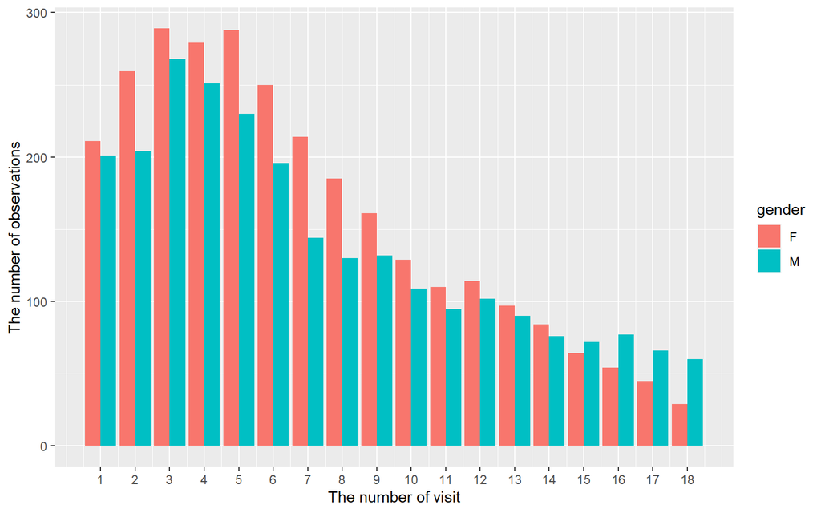

```r
new_blsa_clean %>%
  select(gender, visit, bmi:AFG) %>%
  ggplot(aes(x = visit, fill = gender)) +
  geom_bar(position = "dodge") +
  labs(x = "The number of visit", y = "The number of observations") +
  scale_x_continuous(breaks = seq(1, 18, 1))
```

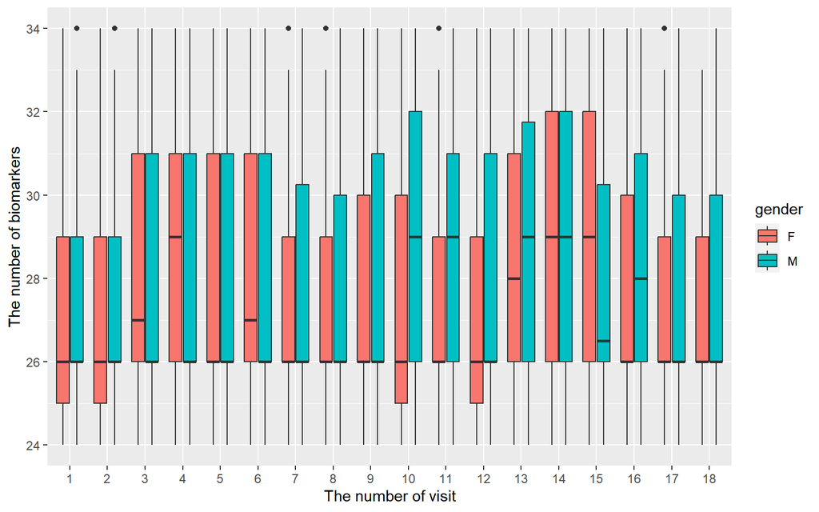

```r
new_blsa_clean %>%
  select(id, gender, visit, bmi:AFG) %>%
  rowwise() %>%
  mutate(nonmissing_count = sum(!is.na(c_across(bmi:AFG)))) %>%
  ggplot(aes(x = factor(visit), y = nonmissing_count, fill = gender)) +
  geom_boxplot() +
  labs(x = "The number of visit", y = "The number of biomarkers")
```

# Distributions for each of biomarker in new_blsa_clean:

## Adiponectin (ug/mL)

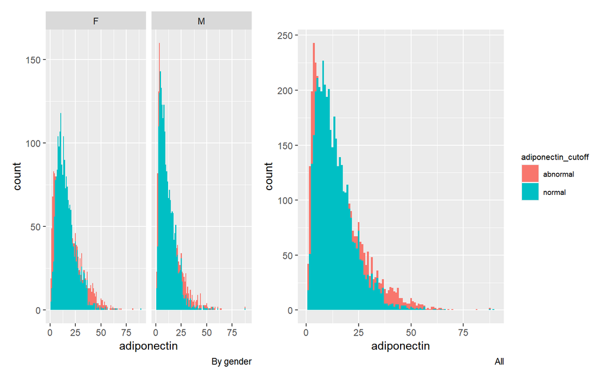

```r
adiponectin_gender_plot =
  new_blsa_clean %>%
  ggplot() +
  geom_histogram(aes(x = adiponectin, fill = adiponectin_cutoff), bins = 100) +
  facet_wrap(~gender) +
  theme(legend.position = "none") +
  labs(caption = "By gender") +
  scale_fill_discrete(breaks = c("abnormal", "normal"))


adiponectin_all_plot =
  new_blsa_clean %>%
  ggplot() +
  geom_histogram(aes(x = adiponectin, fill = adiponectin_cutoff), bins = 100) +
  theme(legend.text = element_text(size = 7),
             legend.title = element_text(size = 8)) +
  labs(caption = "All") +
  scale_fill_discrete(breaks = c("abnormal", "normal"))

adiponectin_fig = adiponectin_gender_plot + adiponectin_all_plot
adiponectin_fig
```

## ALBUMIN (g/dL)

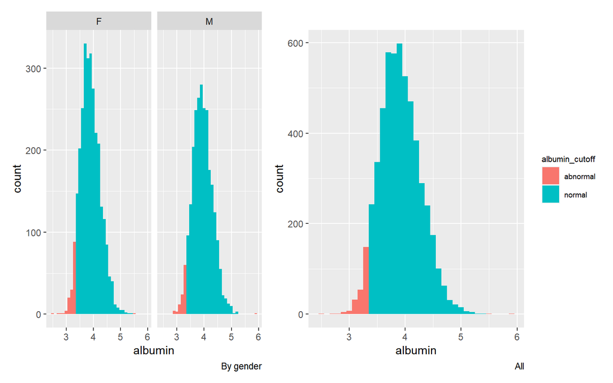

```r
albumin_gender_plot =
  new_blsa_clean %>%
  ggplot() +
  geom_histogram(aes(x = albumin, fill = albumin_cutoff), bins = 35) +
  facet_wrap(~gender) +
  theme(legend.position = "none") +
  labs(caption = "By gender")


albumin_all_plot =
  new_blsa_clean %>%
  ggplot() +
  geom_histogram(aes(x = albumin, fill = albumin_cutoff), bins = 35) +
  theme(legend.text = element_text(size = 7),
        legend.title = element_text(size = 8)) +
  labs(caption = "All")

albumin_fig = albumin_gender_plot + albumin_all_plot
albumin_fig
```

## AMYLASE (u/L)

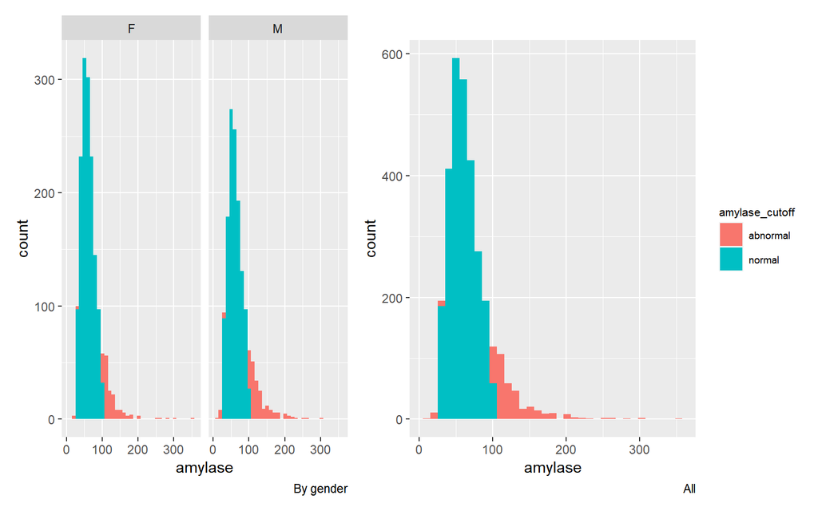

```r
amylase_gender_plot =
  new_blsa_clean %>%
  ggplot() +
  geom_histogram(aes(x = amylase, fill = amylase_cutoff), bins = 35) +
  facet_wrap(~gender) +
  theme(legend.position = "none") +
  labs(caption = "By gender")


amylase_all_plot =
  new_blsa_clean %>%
  ggplot() +
  geom_histogram(aes(x = amylase, fill = amylase_cutoff), bins = 35) +
  theme(legend.text = element_text(size = 7),
        legend.title = element_text(size = 8)) +
  labs(caption = "All")

amylase_fig = amylase_gender_plot + amylase_all_plot
amylase_fig
```

## Adjusted Fasting Glucose value (mg/dl)

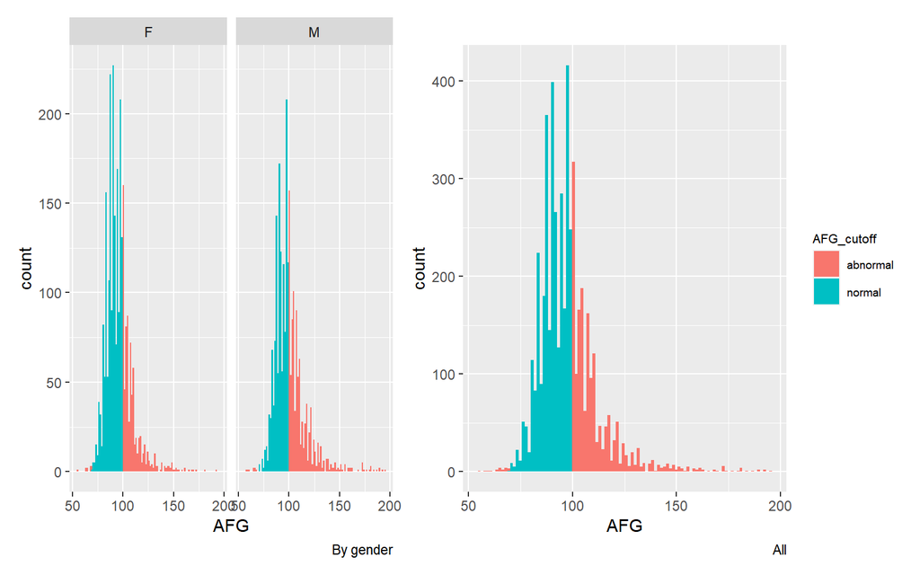

```r
AFG_gender_plot =
  new_blsa_clean %>%
  ggplot() +
  geom_histogram(aes(x = AFG, fill = AFG_cutoff), bins = 100) +
  facet_wrap(~gender) +
  theme(legend.position = "none") +
  labs(caption = "By gender")


AFG_all_plot =
  new_blsa_clean %>%
  ggplot() +
  geom_histogram(aes(x = AFG, fill = AFG_cutoff), bins = 100) +
  theme(legend.text = element_text(size = 7),
        legend.title = element_text(size = 8)) +
  labs(caption = "All")

AFG_fig = AFG_gender_plot + AFG_all_plot
AFG_fig
```

## BMI

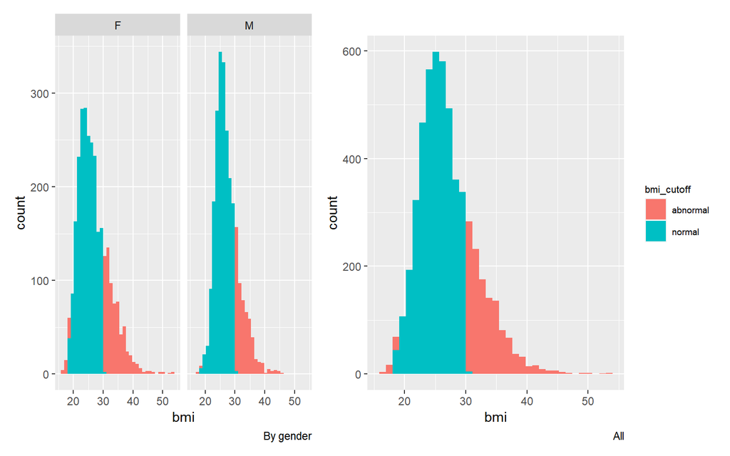

```r
bmi_gender_plot =
  new_blsa_clean %>%
  ggplot() +
  geom_histogram(aes(x = bmi, fill = bmi_cutoff), bins = 35) +
  facet_wrap(~gender) +
  theme(legend.position = "none") +
  labs(caption = "By gender")


bmi_all_plot =
  new_blsa_clean %>%
  ggplot() +
  geom_histogram(aes(x = bmi, fill = bmi_cutoff), bins = 35) +
  theme(legend.text = element_text(size = 7),
        legend.title = element_text(size = 8)) +
  labs(caption = "All")

bmi_fig = bmi_gender_plot + bmi_all_plot
bmi_fig
```

## Bioavailable Testosterone (ng/dL)

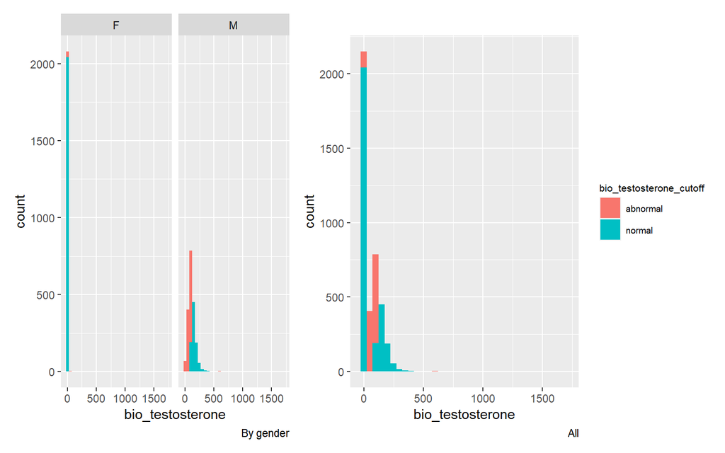

```r
bio_testosterone_gender_plot =
  new_blsa_clean %>%
  ggplot() +
  geom_histogram(aes(x = bio_testosterone, fill = bio_testosterone_cutoff), bins = 35) +
  facet_wrap(~gender) +
  theme(legend.position = "none") +
  labs(caption = "By gender")

bio_testosterone_all_plot =
  new_blsa_clean %>%
  ggplot() +
  geom_histogram(aes(x = bio_testosterone, fill = bio_testosterone_cutoff), bins = 35) +
  theme(legend.text = element_text(size = 7),
        legend.title = element_text(size = 8)) +
  labs(caption = "All")

bio_testosterone_fig = bio_testosterone_gender_plot + bio_testosterone_all_plot
bio_testosterone_fig
```

## CHOLESTEROL (mg/dL)

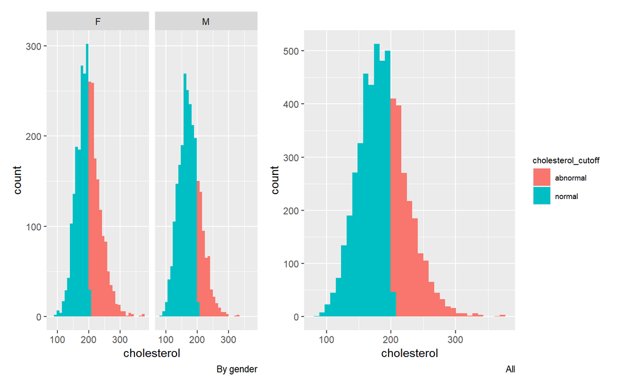

```r
cholesterol_gender_plot =
  new_blsa_clean %>%
  ggplot() +
  geom_histogram(aes(x = cholesterol, fill = cholesterol_cutoff), bins = 35) +
  facet_wrap(~gender) +
  theme(legend.position = "none") +
  labs(caption = "By gender")

cholesterol_all_plot =
  new_blsa_clean %>%
  ggplot() +
  geom_histogram(aes(x = cholesterol, fill = cholesterol_cutoff), bins = 35) +
  theme(legend.text = element_text(size = 7),
        legend.title = element_text(size = 8)) +
  labs(caption = "All")

cholesterol_fig = cholesterol_gender_plot + cholesterol_all_plot
cholesterol_fig
```

## Composed Systolic blood pressure (mmHg)

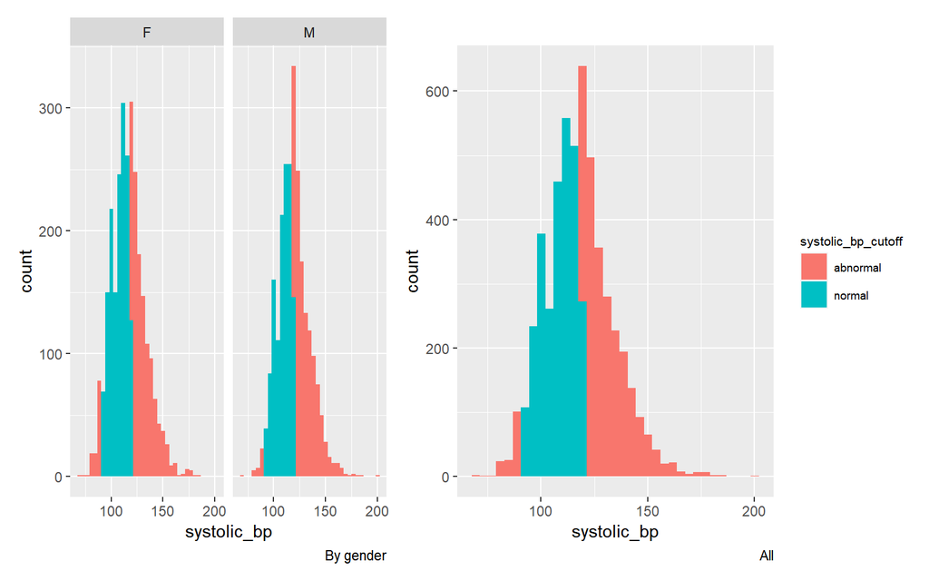

```r
systolic_bp_gender_plot =
  new_blsa_clean %>%
  ggplot() +
  geom_histogram(aes(x = systolic_bp, fill = systolic_bp_cutoff), bins = 35) +
  facet_wrap(~gender) +
  theme(legend.position = "none") +
  labs(caption = "By gender")

systolic_bp_all_plot =
  new_blsa_clean %>%
  ggplot() +
  geom_histogram(aes(x = systolic_bp, fill = systolic_bp_cutoff), bins = 35) +
  theme(legend.text = element_text(size = 7),
        legend.title = element_text(size = 8)) +
  labs(caption = "All")

systolic_bp_fig = systolic_bp_gender_plot + systolic_bp_all_plot
systolic_bp_fig
```

## Composed Diastolic blood pressure (mmHg)

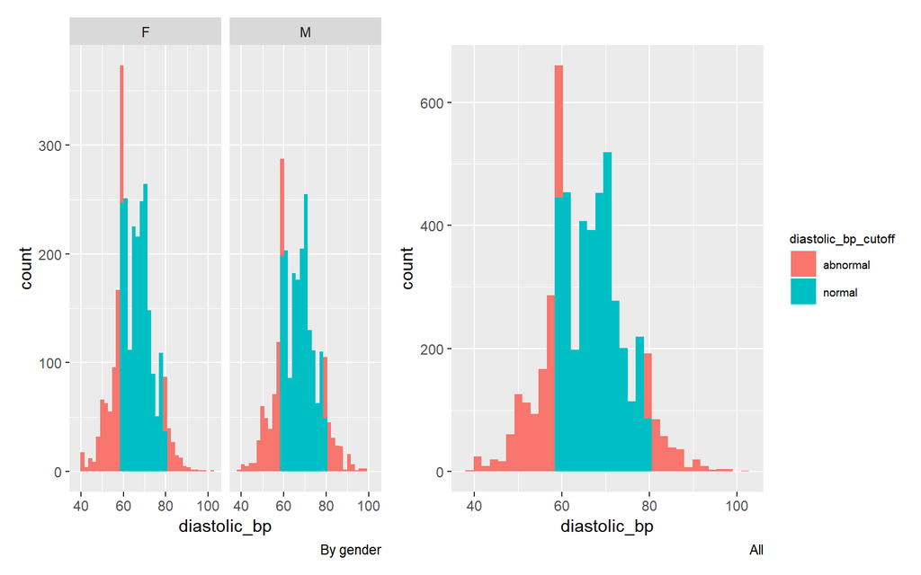

```r
diastolic_bp_gender_plot =
  new_blsa_clean %>%
  ggplot() +
  geom_histogram(aes(x = diastolic_bp, fill = diastolic_bp_cutoff), bins = 35) +
  facet_wrap(~gender) +
  theme(legend.position = "none") +
  labs(caption = "By gender")

diastolic_bp_all_plot =
  new_blsa_clean %>%
  ggplot() +
  geom_histogram(aes(x = diastolic_bp, fill = diastolic_bp_cutoff), bins = 35) +
  theme(legend.text = element_text(size = 7),
        legend.title = element_text(size = 8)) +
  labs(caption = "All")

diastolic_bp_fig = diastolic_bp_gender_plot + diastolic_bp_all_plot
diastolic_bp_fig
```

## CREATININE, SERUM (mg/dL)

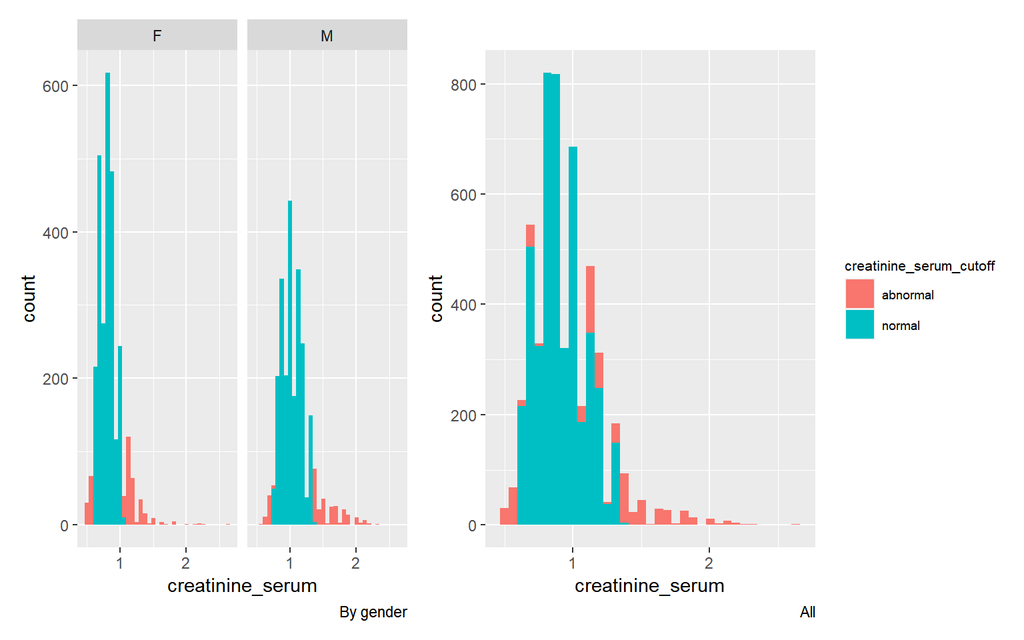

```r
creatinine_serum_gender_plot =
  new_blsa_clean %>%
  ggplot() +
  geom_histogram(aes(x = creatinine_serum, fill = creatinine_serum_cutoff), bins = 35) +
  facet_wrap(~gender) +
  theme(legend.position = "none") +
  labs(caption = "By gender")

creatinine_serum_all_plot =
  new_blsa_clean %>%
  ggplot() +
  geom_histogram(aes(x = creatinine_serum, fill = creatinine_serum_cutoff), bins = 35) +
  theme(legend.text = element_text(size = 7),
        legend.title = element_text(size = 8)) +
  labs(caption = "All")

creatinine_serum_fig = creatinine_serum_gender_plot + creatinine_serum_all_plot
creatinine_serum_fig
```

## CRP (ug/mL)

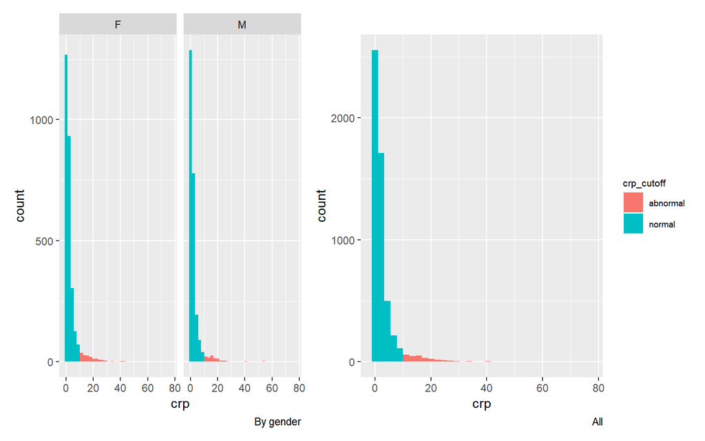

```r
crp_gender_plot =
  new_blsa_clean %>%
  ggplot() +
  geom_histogram(aes(x = crp, fill = crp_cutoff), bins = 35) +
  facet_wrap(~gender) +
  theme(legend.position = "none") +
  labs(caption = "By gender")

crp_all_plot =
  new_blsa_clean %>%
  ggplot() +
  geom_histogram(aes(x = crp, fill = crp_cutoff), bins = 35) +
  theme(legend.text = element_text(size = 7),
        legend.title = element_text(size = 8)) +
  labs(caption = "All")

crp_fig = crp_gender_plot + crp_all_plot
crp_fig
```

## Dehydroepiandrsterone Sulfate (ug/dL)

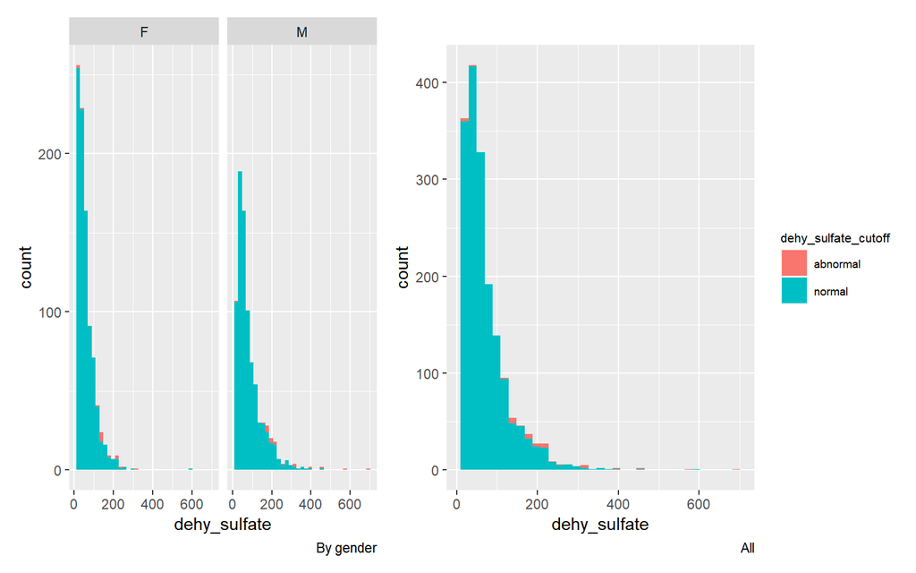

```r
dehy_sulfate_gender_plot =
  new_blsa_clean %>%
  ggplot() +
  geom_histogram(aes(x = dehy_sulfate, fill = dehy_sulfate_cutoff), bins = 35) +
  facet_wrap(~gender) +
  theme(legend.position = "none") +
  labs(caption = "By gender")

dehy_sulfate_all_plot =
  new_blsa_clean %>%
  ggplot() +
  geom_histogram(aes(x = dehy_sulfate, fill = dehy_sulfate_cutoff), bins = 35) +
  theme(legend.text = element_text(size = 7),
        legend.title = element_text(size = 8)) +
  labs(caption = "All")

dehy_sulfate_fig = dehy_sulfate_gender_plot + dehy_sulfate_all_plot
dehy_sulfate_fig
```

## Estradiol (ng/DL)

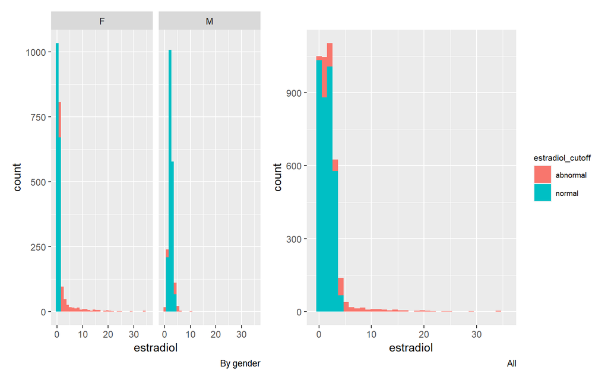

```r
estradiol_gender_plot =
  new_blsa_clean %>%
  ggplot() +
  geom_histogram(aes(x = estradiol, fill = estradiol_cutoff), bins = 35) +
  facet_wrap(~gender) +
  theme(legend.position = "none") +
  labs(caption = "By gender")

estradiol_all_plot =
  new_blsa_clean %>%
  ggplot() +
  geom_histogram(aes(x = estradiol, fill = estradiol_cutoff), bins = 35) +
  theme(legend.text = element_text(size = 7),
        legend.title = element_text(size = 8)) +
  labs(caption = "All")

estradiol_fig = estradiol_gender_plot + estradiol_all_plot
estradiol_fig
```

## FREE T3 (pg/mL)

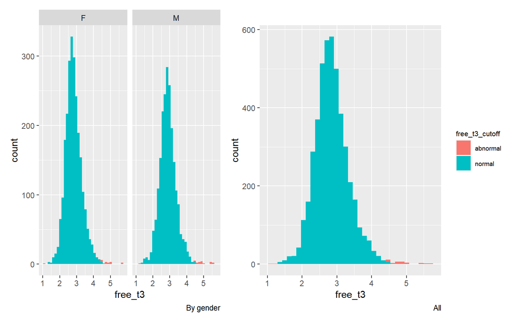

```r
free_t3_gender_plot =
  new_blsa_clean %>%
  ggplot() +
  geom_histogram(aes(x = free_t3, fill = free_t3_cutoff), bins = 35) +
  facet_wrap(~gender) +
  theme(legend.position = "none") +
  labs(caption = "By gender")

free_t3_all_plot =
  new_blsa_clean %>%
  ggplot() +
  geom_histogram(aes(x = free_t3, fill = free_t3_cutoff), bins = 35) +
  theme(legend.text = element_text(size = 7),
        legend.title = element_text(size = 8)) +
  labs(caption = "All")

free_t3_fig = free_t3_gender_plot + free_t3_all_plot
free_t3_fig
```

## Free T4 (ng/ml)

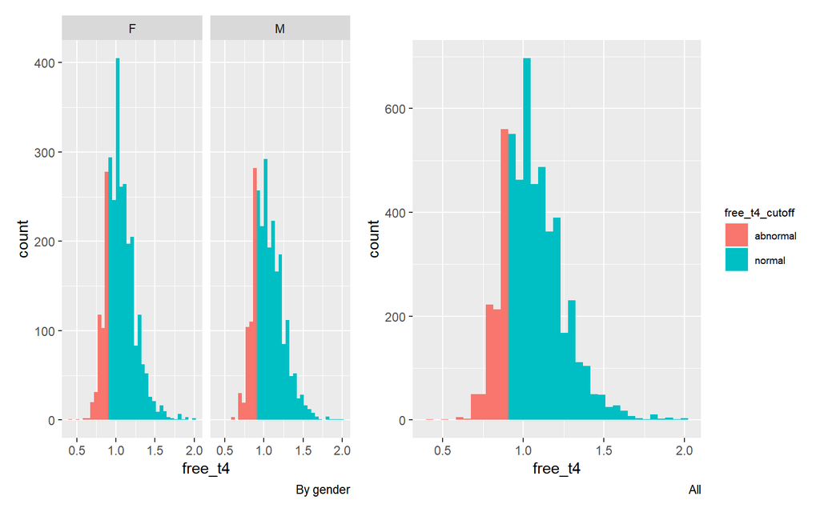

```r
free_t4_gender_plot =
  new_blsa_clean %>%
  ggplot() +
  geom_histogram(aes(x = free_t4, fill = free_t4_cutoff), bins = 35) +
  facet_wrap(~gender) +
  theme(legend.position = "none") +
  labs(caption = "By gender")

free_t4_all_plot =
  new_blsa_clean %>%
  ggplot() +
  geom_histogram(aes(x = free_t4, fill = free_t4_cutoff), bins = 35) +
  theme(legend.text = element_text(size = 7),
        legend.title = element_text(size = 8)) +
  labs(caption = "All")

free_t4_fig = free_t4_gender_plot + free_t4_all_plot
free_t4_fig
```

## Homocysteine (umol/L)

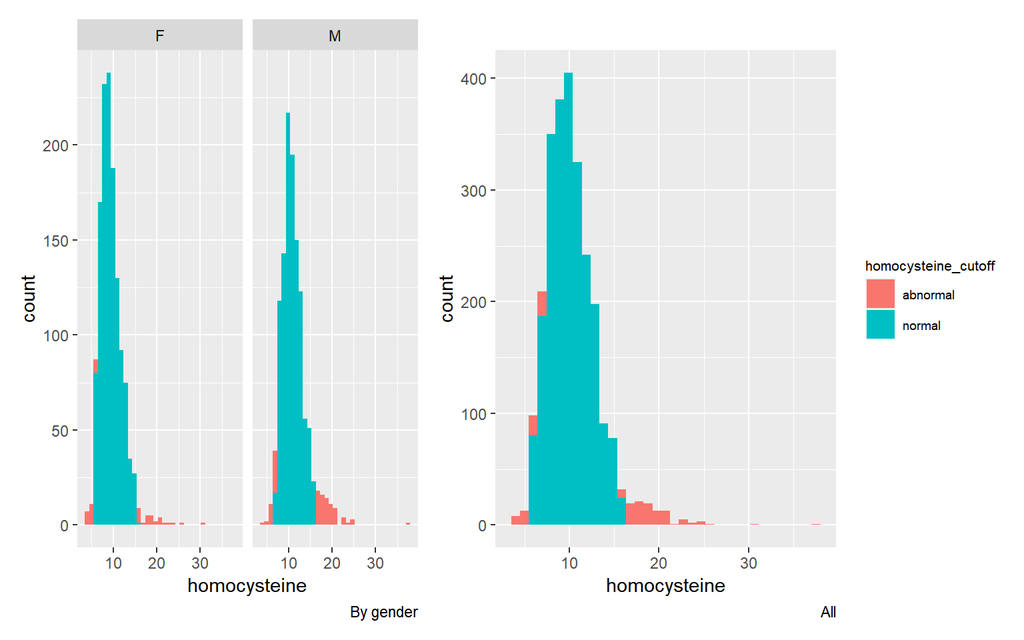

```r
homocysteine_gender_plot =
  new_blsa_clean %>%
  ggplot() +
  geom_histogram(aes(x = homocysteine, fill = homocysteine_cutoff), bins = 35) +
  facet_wrap(~gender) +
  theme(legend.position = "none") +
  labs(caption = "By gender")

homocysteine_all_plot =
  new_blsa_clean %>%
  ggplot() +
  geom_histogram(aes(x = homocysteine, fill = homocysteine_cutoff), bins = 35) +
  theme(legend.text = element_text(size = 7),
        legend.title = element_text(size = 8)) +
  labs(caption = "All")

homocysteine_fig = homocysteine_gender_plot + homocysteine_all_plot
homocysteine_fig
```

## HDL-Cholesterol (mg/dL)

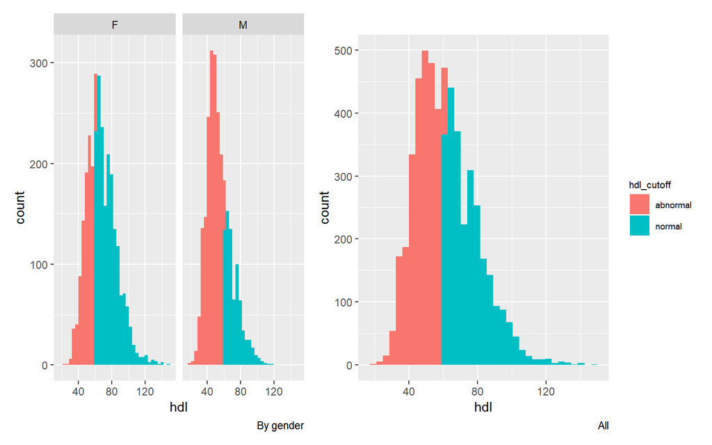

```r
hdl_gender_plot =
  new_blsa_clean %>%
  ggplot() +
  geom_histogram(aes(x = hdl, fill = hdl_cutoff), bins = 35) +
  facet_wrap(~gender) +
  theme(legend.position = "none") +
  labs(caption = "By gender")

hdl_all_plot =
  new_blsa_clean %>%
  ggplot() +
  geom_histogram(aes(x = hdl, fill = hdl_cutoff), bins = 35) +
  theme(legend.text = element_text(size = 7),
        legend.title = element_text(size = 8)) +
  labs(caption = "All")

hdl_fig = hdl_gender_plot + hdl_all_plot
hdl_fig
```

## HBA1C (%)

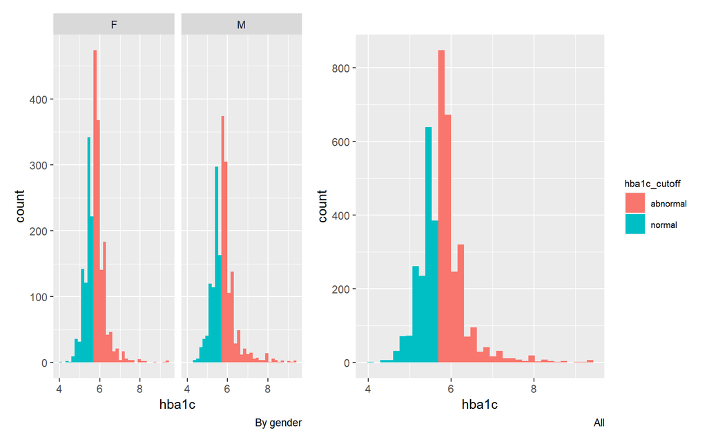

```r
hba1c_gender_plot =
  new_blsa_clean %>%
  ggplot() +
  geom_histogram(aes(x = hba1c, fill = hba1c_cutoff), bins = 35) +
  facet_wrap(~gender) +
  theme(legend.position = "none") +
  labs(caption = "By gender")

hba1c_all_plot =
  new_blsa_clean %>%
  ggplot() +
  geom_histogram(aes(x = hba1c, fill = hba1c_cutoff), bins = 35) +
  theme(legend.text = element_text(size = 7),
        legend.title = element_text(size = 8)) +
  labs(caption = "All")

hba1c_fig = hba1c_gender_plot + hba1c_all_plot
hba1c_fig
```

## IL6 (pg/ml) [per: 0% - 80%]

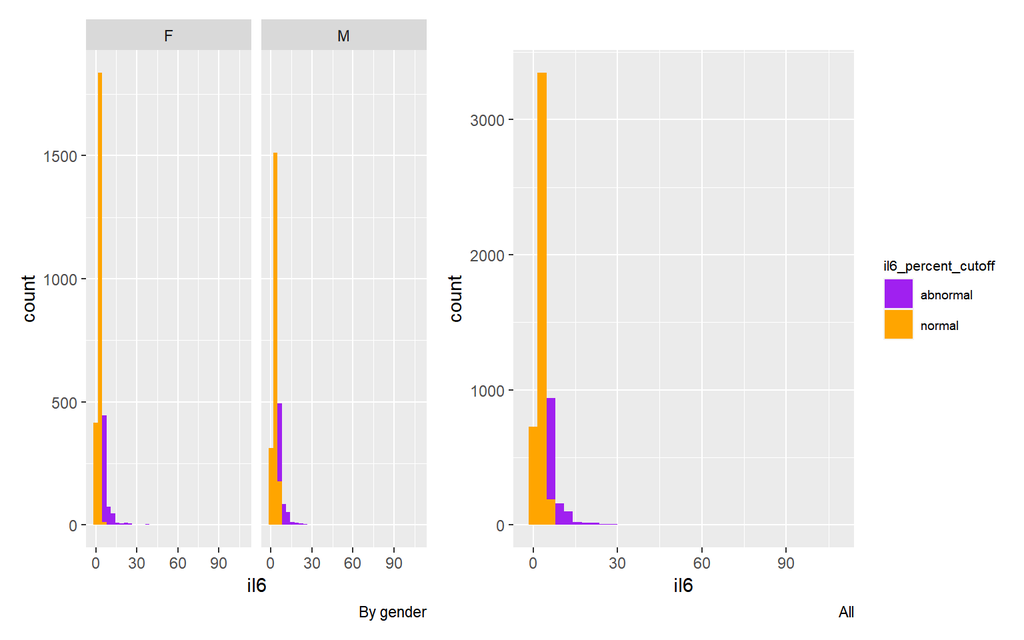

```r
il6_gender_plot =
  new_blsa_clean %>%
  ggplot() +
  geom_histogram(aes(x = il6, fill = il6_percent_cutoff), bins = 35) +
  facet_wrap(~gender) +
  theme(legend.position = "none") +
  labs(caption = "By gender") +
  scale_fill_manual(values = c("purple", "orange"))

il6_all_plot =
  new_blsa_clean %>%
  ggplot() +
  geom_histogram(aes(x = il6, fill = il6_percent_cutoff), bins = 35) +
  theme(legend.text = element_text(size = 7),
        legend.title = element_text(size = 8)) +
  labs(caption = "All") +
  scale_fill_manual(values = c("purple", "orange"))

il6_fig = il6_gender_plot + il6_all_plot
il6_fig
```

## Insulin-like Growth Factor 1 (ng/mL)

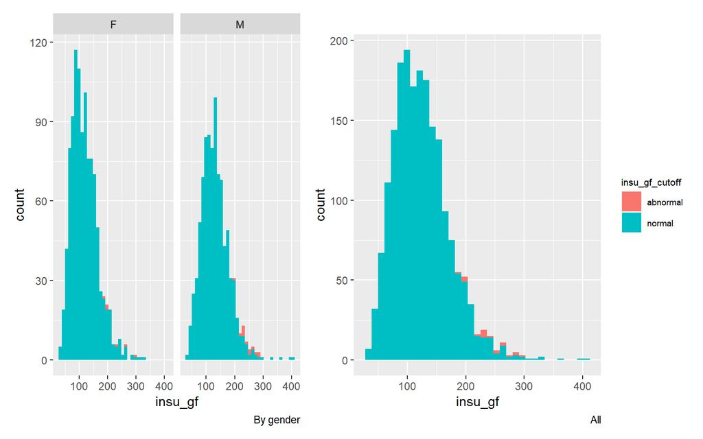

```r
insu_gf_gender_plot =
  new_blsa_clean %>%
  ggplot() +
  geom_histogram(aes(x = insu_gf, fill = insu_gf_cutoff), bins = 35) +
  facet_wrap(~gender) +
  theme(legend.position = "none") +
  labs(caption = "By gender")

insu_gf_all_plot =
  new_blsa_clean %>%
  ggplot() +
  geom_histogram(aes(x = insu_gf, fill = insu_gf_cutoff), bins = 35) +
  theme(legend.text = element_text(size = 7),
        legend.title = element_text(size = 8)) +
  labs(caption = "All")

insu_gf_fig = insu_gf_gender_plot + insu_gf_all_plot
insu_gf_fig
```

## LDL-Cholesterol (mg/dL)

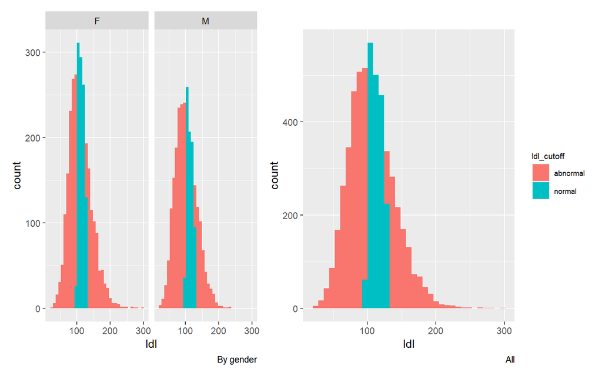

```r
ldl_gender_plot =
  new_blsa_clean %>%
  ggplot() +
  geom_histogram(aes(x = ldl, fill = ldl_cutoff), bins = 35) +
  facet_wrap(~gender) +
  theme(legend.position = "none") +
  labs(caption = "By gender")

ldl_all_plot =
  new_blsa_clean %>%
  ggplot() +
  geom_histogram(aes(x = ldl, fill = ldl_cutoff), bins = 35) +
  theme(legend.text = element_text(size = 7),
        legend.title = element_text(size = 8)) +
  labs(caption = "All")

ldl_fig = ldl_gender_plot + ldl_all_plot
ldl_fig
```

## Plasminogen Activator Inhibitor 1 (ng/mL) [per: 0% - 80%]

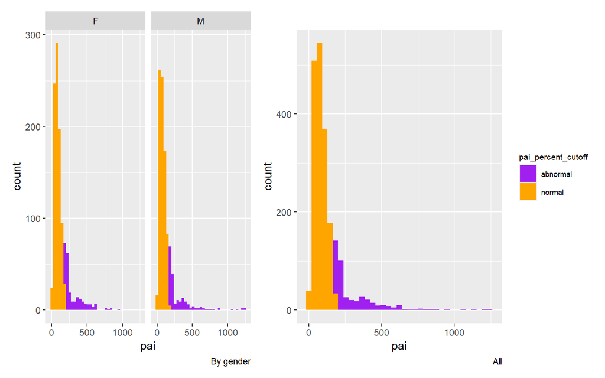

```r
pai_gender_plot =
  new_blsa_clean %>%
  ggplot() +
  geom_histogram(aes(x = pai, fill = pai_percent_cutoff), bins = 35) +
  facet_wrap(~gender) +
  theme(legend.position = "none") +
  labs(caption = "By gender") +
  scale_fill_manual(values = c("purple", "orange"))

pai_all_plot =
  new_blsa_clean %>%
  ggplot() +
  geom_histogram(aes(x = pai, fill = pai_percent_cutoff), bins = 35) +
  theme(legend.text = element_text(size = 7),
        legend.title = element_text(size = 8)) +
  labs(caption = "All") +
  scale_fill_manual(values = c("purple", "orange"))

pai_fig = pai_gender_plot + pai_all_plot
pai_fig
```

## Resistin (ng/mL) [per: 0% - 80%]

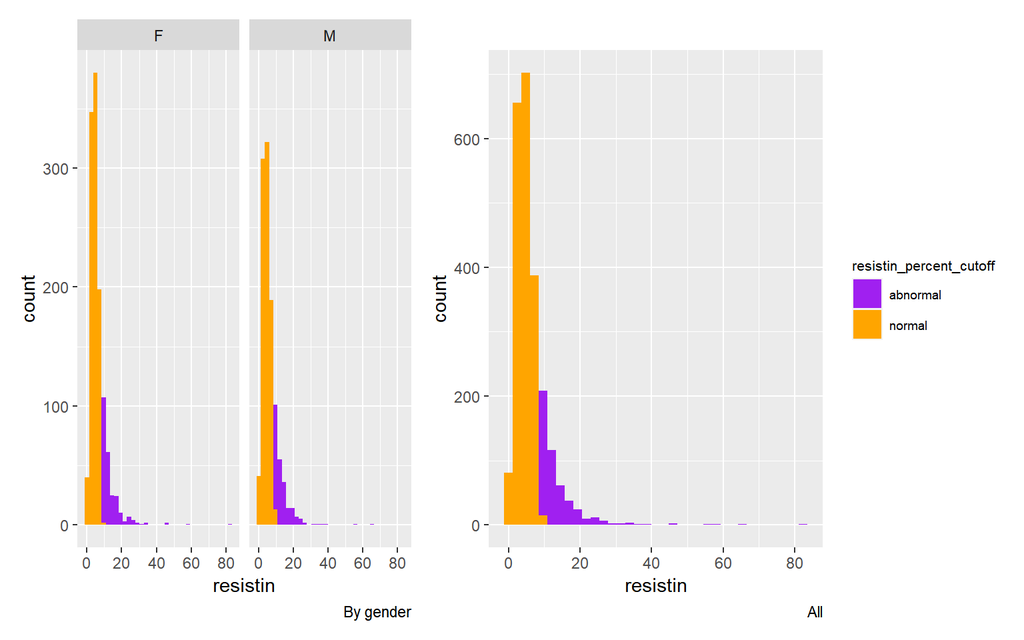

```r
resistin_gender_plot =
  new_blsa_clean %>%
  ggplot() +
  geom_histogram(aes(x = resistin, fill = resistin_percent_cutoff), bins = 35) +
  facet_wrap(~gender) +
  theme(legend.position = "none") +
  labs(caption = "By gender") +
  scale_fill_manual(values = c("purple", "orange"))

resistin_all_plot =
  new_blsa_clean %>%
  ggplot() +
  geom_histogram(aes(x = resistin, fill = resistin_percent_cutoff), bins = 35) +
  theme(legend.text = element_text(size = 7),
        legend.title = element_text(size = 8)) +
  labs(caption = "All") +
  scale_fill_manual(values = c("purple", "orange"))

resistin_fig = resistin_gender_plot + resistin_all_plot
resistin_fig
```

## Serum Cortisol (ug/dL) (For the morning)

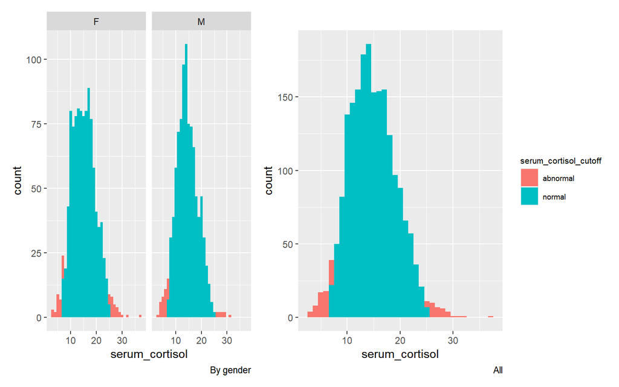

```r
serum_cortisol_gender_plot =
  new_blsa_clean %>%
  ggplot() +
  geom_histogram(aes(x = serum_cortisol, fill = serum_cortisol_cutoff), bins = 35) +
  facet_wrap(~gender) +
  theme(legend.position = "none") +
  labs(caption = "By gender") +
  scale_fill_discrete(breaks = c("abnormal", "normal"))

serum_cortisol_all_plot =
  new_blsa_clean %>%
  ggplot() +
  geom_histogram(aes(x = serum_cortisol, fill = serum_cortisol_cutoff), bins = 35) +
  theme(legend.text = element_text(size = 7),
        legend.title = element_text(size = 8)) +
  labs(caption = "All") +
  scale_fill_discrete(breaks = c("abnormal", "normal"))

serum_cortisol_fig = serum_cortisol_gender_plot + serum_cortisol_all_plot
serum_cortisol_fig
```

## Sodium (mmol/L)

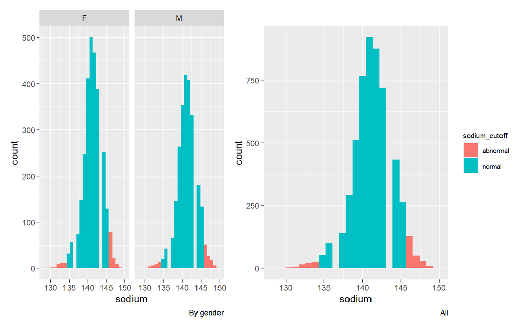

```r
sodium_gender_plot =
  new_blsa_clean %>%
  ggplot() +
  geom_histogram(aes(x = sodium, fill = sodium_cutoff), bins = 25) +
  facet_wrap(~gender) +
  theme(legend.position = "none") +
  labs(caption = "By gender") +
  scale_fill_discrete(breaks = c("abnormal", "normal"))

sodium_all_plot =
  new_blsa_clean %>%
  ggplot() +
  geom_histogram(aes(x = sodium, fill = sodium_cutoff), bins = 25) +
  theme(legend.text = element_text(size = 7),
        legend.title = element_text(size = 8)) +
  labs(caption = "All") +
  scale_fill_discrete(breaks = c("abnormal", "normal"))

sodium_fig = sodium_gender_plot + sodium_all_plot
sodium_fig
```